# Ejercicio de machine learning 2: Alquiler de bicicletas

Se procede a crear una función de extracción del día del mes DD a partir de una fecha del tipo date, es decir, YYYY-MM-DD para que luego sea aplicada a toda la columna date del dataframe en la creación de la nueva variable monthday.

```python
def extraccion_dia(string):
    dia = int(string[8]) * 10 + int(string[9])
    return dia
```

```python
# Pruebas de la función extraccion_dia
extraccion_dia("2011-01-01 00:00:00")
```

```
1
```

```python
extraccion_dia("2012-12-31 20:00:00")
```

```
31
```

Con el objetivo de que quede más limpio, se crea justo a continuación de la columna month.

```python
bike_rentals_dataset.insert(7, "monthday", bike_rentals_dataset["date"].apply(extraccion_dia))
```

```python
bike_rentals_dataset
```

|  | date | season__spring | season__summer | season__autumn | season__winter | year | month | monthday | hour | weekday | ... | weather__Heavy Rain + Ice Pallets + Thunderstorm + Mist/Snow + Fog | temperature | thermal_sensation | humidity | windspeed | season__spring_MAL | season__summer_MAL | season__autumn_MAL | season__winter_MAL | number_of_rentals |
| --- | --- | --- | --- | --- | --- | --- | --- | --- | --- | --- | --- | --- | --- | --- | --- | --- | --- | --- | --- | --- | --- |
| 0 | 2011-01-01 00:00:00 | 0 | 0 | 0 | 1 | 2011 | 1 | 1 | 0 | 6 | ... | 0 | 9.84 | 14.395 | 81.0 | 0.0000 | 1 | 0 | 0 | 0 | 16 |
| 1 | 2011-01-01 01:00:00 | 0 | 0 | 0 | 1 | 2011 | 1 | 1 | 1 | 6 | ... | 0 | 9.02 | 13.635 | 80.0 | 0.0000 | 1 | 0 | 0 | 0 | 40 |
| 2 | 2011-01-01 02:00:00 | 0 | 0 | 0 | 1 | 2011 | 1 | 1 | 2 | 6 | ... | 0 | 9.02 | 13.635 | 80.0 | 0.0000 | 1 | 0 | 0 | 0 | 32 |
| 3 | 2011-01-01 03:00:00 | 0 | 0 | 0 | 1 | 2011 | 1 | 1 | 3 | 6 | ... | 0 | 9.84 | 14.395 | 75.0 | 0.0000 | 1 | 0 | 0 | 0 | 13 |
| 4 | 2011-01-01 04:00:00 | 0 | 0 | 0 | 1 | 2011 | 1 | 1 | 4 | 6 | ... | 0 | 9.84 | 14.395 | 75.0 | 0.0000 | 1 | 0 | 0 | 0 | 1 |
| ... | ... | ... | ... | ... | ... | ... | ... | ... | ... | ... | ... | ... | ... | ... | ... | ... | ... | ... | ... | ... | ... |
| 17374 | 2012-12-31 19:00:00 | 0 | 0 | 0 | 1 | 2012 | 12 | 31 | 19 | 1 | ... | 0 | 10.66 | 12.880 | 60.0 | 11.0014 | 1 | 0 | 0 | 0 | 119 |
| 17375 | 2012-12-31 20:00:00 | 0 | 0 | 0 | 1 | 2012 | 12 | 31 | 20 | 1 | ... | 0 | 10.66 | 12.880 | 60.0 | 11.0014 | 1 | 0 | 0 | 0 | 89 |
| 17376 | 2012-12-31 21:00:00 | 0 | 0 | 0 | 1 | 2012 | 12 | 31 | 21 | 1 | ... | 0 | 10.66 | 12.880 | 60.0 | 11.0014 | 1 | 0 | 0 | 0 | 90 |
| 17377 | 2012-12-31 22:00:00 | 0 | 0 | 0 | 1 | 2012 | 12 | 31 | 22 | 1 | ... | 0 | 10.66 | 13.635 | 56.0 | 8.9981 | 1 | 0 | 0 | 0 | 61 |
| 17378 | 2012-12-31 23:00:00 | 0 | 0 | 0 | 1 | 2012 | 12 | 31 | 23 | 1 | ... | 0 | 10.66 | 13.635 | 65.0 | 8.9981 | 1 | 0 | 0 | 0 | 49 |

17379 rows × 25 columns

Se compueba la coherencia de los datos de monthday, para asegurarse de que no ha ocurrido nada inesperado en el proceso (nada que llame la atención) que obligase a un análisis más profundo de los datos date.

```python
bike_rentals_dataset["monthday"].isnull().sum()
```

```
0
```

```python
pd.value_counts(bike_rentals_dataset["monthday"])
```

```
9     575
1     575
17    575
5     575
8     574
19    574
4     574
20    574
21    574
7     574
15    574
16    574
14    574
13    574
12    573
```

[output cut: 17 more lines]

Se procede a cambiar los nombres de las cuatro variables weather a otros de un tamaño más reducido, para hacerlos así más manejables y comprensibles.

```python
bike_rentals_dataset = bike_rentals_dataset.rename(columns={'weather__Clear/Few clouds/Partly cloudy/Partly cloudy':'weather__Clear_Fewclouds',
 'weather__Mist + Cloudy/Mist + Broken clouds/Mist + Few clouds/Mist': 'weather__Mist',
 'weather__Light Snow/Light Rain + Thunderstorm + Scattered clouds/Light Rain + Scattered clouds':'weather__Light',
 'weather__Heavy Rain + Ice Pallets + Thunderstorm + Mist/Snow + Fog':'weather__Heavy'})
```

Se elimina la columna date y los duplicados erróneos de season: season**spring_MAL, season**summer_MAL, season**autumn_MAL y season**winter_MAL.

```python
bike_rentals_dataset = bike_rentals_dataset.drop(columns=['date',
                                                          'season__spring_MAL',
                                                          'season__summer_MAL',
                                                          'season__autumn_MAL',
                                                          'season__winter_MAL'])
```

```python
bike_rentals_dataset_columnas_features = bike_rentals_dataset.loc[:, bike_rentals_dataset.columns != 'number_of_rentals']
```

```python
columns_names_features = bike_rentals_dataset_columnas_features.columns.values
```

```python
features = list(columns_names_features)
```

```python
features
```

```
['season__spring',
 'season__summer',
 'season__autumn',
 'season__winter',
 'year',
 'month',
 'monthday',
 'hour',
 'weekday',
 'holiday',
 'workingday',
 'weather__Clear_Fewclouds',
 'weather__Mist',
 'weather__Light',
 'weather__Heavy',
 'temperature',
 'thermal_sensation',
 'humidity',
 'windspeed']
```

```python
bike_rentals_dataset
```

|  | season__spring | season__summer | season__autumn | season__winter | year | month | monthday | hour | weekday | holiday | workingday | weather__Clear_Fewclouds | weather__Mist | weather__Light | weather__Heavy | temperature | thermal_sensation | humidity | windspeed | number_of_rentals |
| --- | --- | --- | --- | --- | --- | --- | --- | --- | --- | --- | --- | --- | --- | --- | --- | --- | --- | --- | --- | --- |
| 0 | 0 | 0 | 0 | 1 | 2011 | 1 | 1 | 0 | 6 | 0 | 0 | 1 | 0 | 0 | 0 | 9.84 | 14.395 | 81.0 | 0.0000 | 16 |
| 1 | 0 | 0 | 0 | 1 | 2011 | 1 | 1 | 1 | 6 | 0 | 0 | 1 | 0 | 0 | 0 | 9.02 | 13.635 | 80.0 | 0.0000 | 40 |
| 2 | 0 | 0 | 0 | 1 | 2011 | 1 | 1 | 2 | 6 | 0 | 0 | 1 | 0 | 0 | 0 | 9.02 | 13.635 | 80.0 | 0.0000 | 32 |
| 3 | 0 | 0 | 0 | 1 | 2011 | 1 | 1 | 3 | 6 | 0 | 0 | 1 | 0 | 0 | 0 | 9.84 | 14.395 | 75.0 | 0.0000 | 13 |
| 4 | 0 | 0 | 0 | 1 | 2011 | 1 | 1 | 4 | 6 | 0 | 0 | 1 | 0 | 0 | 0 | 9.84 | 14.395 | 75.0 | 0.0000 | 1 |
| ... | ... | ... | ... | ... | ... | ... | ... | ... | ... | ... | ... | ... | ... | ... | ... | ... | ... | ... | ... | ... |
| 17374 | 0 | 0 | 0 | 1 | 2012 | 12 | 31 | 19 | 1 | 0 | 1 | 0 | 1 | 0 | 0 | 10.66 | 12.880 | 60.0 | 11.0014 | 119 |
| 17375 | 0 | 0 | 0 | 1 | 2012 | 12 | 31 | 20 | 1 | 0 | 1 | 0 | 1 | 0 | 0 | 10.66 | 12.880 | 60.0 | 11.0014 | 89 |
| 17376 | 0 | 0 | 0 | 1 | 2012 | 12 | 31 | 21 | 1 | 0 | 1 | 1 | 0 | 0 | 0 | 10.66 | 12.880 | 60.0 | 11.0014 | 90 |
| 17377 | 0 | 0 | 0 | 1 | 2012 | 12 | 31 | 22 | 1 | 0 | 1 | 1 | 0 | 0 | 0 | 10.66 | 13.635 | 56.0 | 8.9981 | 61 |
| 17378 | 0 | 0 | 0 | 1 | 2012 | 12 | 31 | 23 | 1 | 0 | 1 | 1 | 0 | 0 | 0 | 10.66 | 13.635 | 65.0 | 8.9981 | 49 |

17379 rows × 20 columns

```python
bike_rentals_dataset.describe()
```

|  | season__spring | season__summer | season__autumn | season__winter | year | month | monthday | hour | weekday | holiday | workingday | weather__Clear_Fewclouds | weather__Mist | weather__Light | weather__Heavy | temperature | thermal_sensation | humidity | windspeed | number_of_rentals |
| --- | --- | --- | --- | --- | --- | --- | --- | --- | --- | --- | --- | --- | --- | --- | --- | --- | --- | --- | --- | --- |
| count | 17379.000000 | 17379.000000 | 17379.000000 | 17379.000000 | 17379.000000 | 17379.000000 | 17379.000000 | 17379.000000 | 17379.000000 | 17379.000000 | 17379.000000 | 17379.000000 | 17379.000000 | 17379.000000 | 17379.000000 | 17379.000000 | 17379.000000 | 17379.000000 | 17379.000000 | 17379.000000 |
| mean | 0.253697 | 0.258703 | 0.243512 | 0.244088 | 2011.502561 | 6.537775 | 15.683411 | 11.546752 | 4.011451 | 0.028770 | 0.682721 | 0.656712 | 0.261465 | 0.081650 | 0.000173 | 20.376474 | 23.788755 | 62.722884 | 12.736540 | 189.463088 |
| std | 0.435139 | 0.437935 | 0.429214 | 0.429557 | 0.500008 | 3.438776 | 8.789373 | 6.914405 | 2.001966 | 0.167165 | 0.465431 | 0.474820 | 0.439445 | 0.273839 | 0.013138 | 7.894801 | 8.592511 | 19.292983 | 8.196795 | 181.387599 |
| min | 0.000000 | 0.000000 | 0.000000 | 0.000000 | 2011.000000 | 1.000000 | 1.000000 | 0.000000 | 1.000000 | 0.000000 | 0.000000 | 0.000000 | 0.000000 | 0.000000 | 0.000000 | 0.820000 | 0.000000 | 0.000000 | 0.000000 | 1.000000 |
| 25% | 0.000000 | 0.000000 | 0.000000 | 0.000000 | 2011.000000 | 4.000000 | 8.000000 | 6.000000 | 2.000000 | 0.000000 | 0.000000 | 0.000000 | 0.000000 | 0.000000 | 0.000000 | 13.940000 | 16.665000 | 48.000000 | 7.001500 | 40.000000 |
| 50% | 0.000000 | 0.000000 | 0.000000 | 0.000000 | 2012.000000 | 7.000000 | 16.000000 | 12.000000 | 4.000000 | 0.000000 | 1.000000 | 1.000000 | 0.000000 | 0.000000 | 0.000000 | 20.500000 | 24.240000 | 63.000000 | 12.998000 | 142.000000 |
| 75% | 1.000000 | 1.000000 | 0.000000 | 0.000000 | 2012.000000 | 10.000000 | 23.000000 | 18.000000 | 6.000000 | 0.000000 | 1.000000 | 1.000000 | 1.000000 | 0.000000 | 0.000000 | 27.060000 | 31.060000 | 78.000000 | 16.997900 | 281.000000 |
| max | 1.000000 | 1.000000 | 1.000000 | 1.000000 | 2012.000000 | 12.000000 | 31.000000 | 23.000000 | 7.000000 | 1.000000 | 1.000000 | 1.000000 | 1.000000 | 1.000000 | 1.000000 | 41.000000 | 50.000000 | 100.000000 | 56.996900 | 977.000000 |

Se usa el método isnull() y sum() para saber si existen registros nulos en el dataframe por columna:

```python
bike_rentals_dataset.isnull().sum()
```

```
season__spring              0
season__summer              0
season__autumn              0
season__winter              0
year                        0
month                       0
monthday                    0
hour                        0
weekday                     0
holiday                     0
workingday                  0
weather__Clear_Fewclouds    0
weather__Mist               0
weather__Light              0
weather__Heavy              0
temperature                 0
thermal_sensation           0
humidity                    0
windspeed                   0
number_of_rentals           0
dtype: int64
```

```python
bike_rentals_dataset.isnull().sum().sum()
```

```
0
```

Se constata la no presencia de valores nulos en el dataframe.

Se considera interesante tener una primera visión de la distribución del número de bicicletas alquiladas.

```
(1.0, 977.0)
```

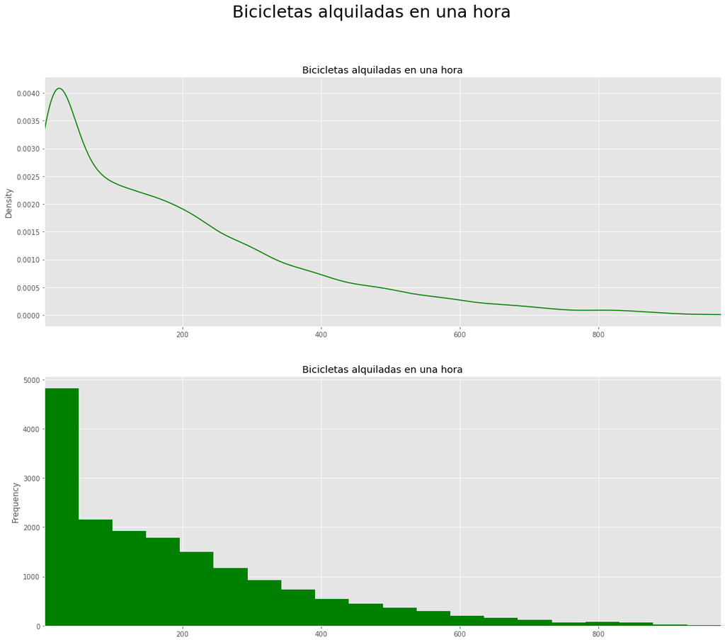

```python
plt.suptitle("Bicicletas alquiladas en una hora", fontsize = 25)

plt.subplot(211)
bike_rentals_dataset["number_of_rentals"].plot(kind="kde",
                                               title="Bicicletas alquiladas en una hora",
                                               figsize=(18,15),
                                               color="green")
plt.xlim([1,977])

plt.subplot(212)
bike_rentals_dataset["number_of_rentals"].plot(kind="hist",
                                               title="Bicicletas alquiladas en una hora",
                                               figsize=(18,15),
                                               bins=20,
                                               color="green")
plt.xlim([1,977])
```

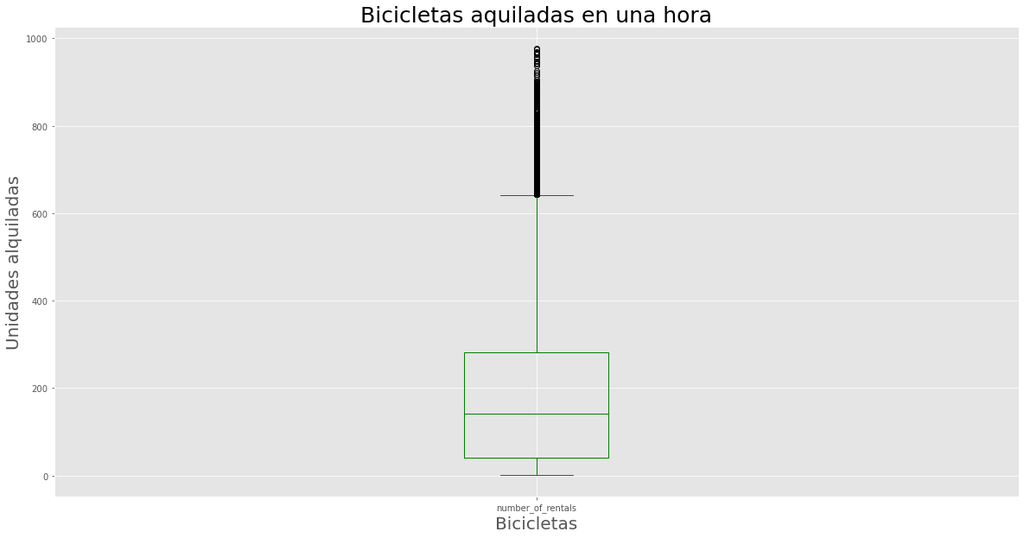

```python
bike_rentals_dataset["number_of_rentals"].plot(kind = "box", figsize = (20, 10), color = "green")
plt.title("Bicicletas aquiladas en una hora", fontsize = 25)
plt.xlabel("Bicicletas", fontsize = 20)
plt.ylabel("Unidades alquiladas", fontsize = 20)
```

```python
bike_rentals_dataset["number_of_rentals"].describe()
```

```
count    17379.000000
mean       189.463088
std        181.387599
min          1.000000
25%         40.000000
50%        142.000000
75%        281.000000
max        977.000000
Name: number_of_rentals, dtype: float64
```

Se observa que el grueso del número de bicicletas alquiladas se encuentra entre los valores de 40 y 281. A partir de un número de alquiler de bicis de 643, el número de alquiladas se considerará como atípico. Todos los días se han alquilado bicis, al menos una (valor mínimo 1).

Se va a intentar ser sistemático en el análisis más profundo que se desarrollará a partir de lo obtenido hasta aquí. ¿De qué forma? Separando en tres grupos las features. Primero, las relativas a las cuatro estaciones, a continuación otras que llamaremos temporales y finalmente las climatológicas.

1.- Estaciones: primavera, verano, otoño e invierno.

'season**spring', 'season**summer', 'season**autumn', 'season**winter'

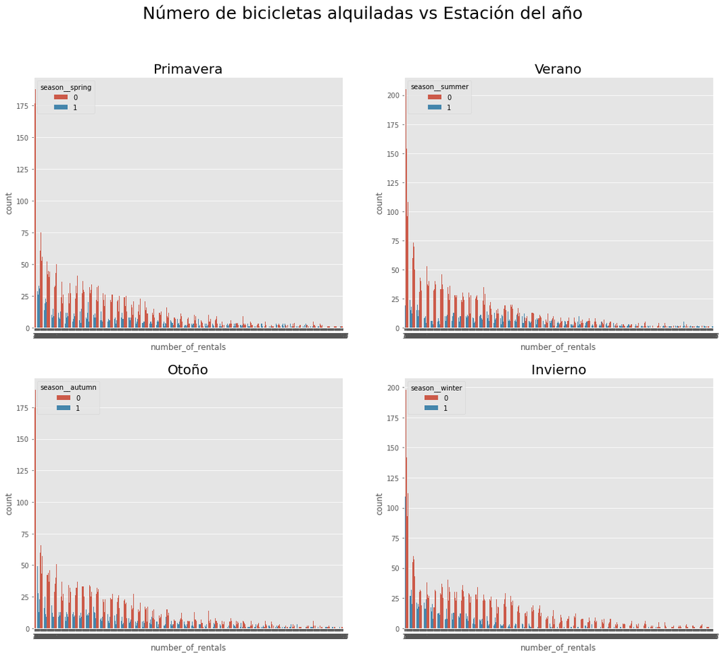

```python
plt.figure(figsize=(18,15))
plt.suptitle("Número de bicicletas alquiladas vs Estación del año", fontsize = 25)

gs = gridspec.GridSpec(2, 2)

plt.subplot(gs[0, 0])
sns.countplot(x='number_of_rentals',
              hue = 'season__spring',
              data=bike_rentals_dataset)
plt.title("Primavera", fontsize = 20)

plt.subplot(gs[0, 1])
sns.countplot(x='number_of_rentals',
              hue = 'season__summer',
              data=bike_rentals_dataset)
plt.title("Verano", fontsize = 20)


plt.subplot(gs[1, 0])
sns.countplot(x='number_of_rentals',
              hue = 'season__autumn',
              data=bike_rentals_dataset)
plt.title("Otoño", fontsize = 20)


plt.subplot(gs[1, 1])
sns.countplot(x='number_of_rentals',
              hue = 'season__winter',
              data=bike_rentals_dataset)
plt.title("Invierno", fontsize = 20)
```

```python
mask = bike_rentals_dataset["season__spring"] == 1
filtrado_1 = bike_rentals_dataset[mask]
filtrado_1["number_of_rentals"].sum()
```

```
918589
```

```python
filtrado_1["number_of_rentals"].describe()
```

```
count    4409.000000
mean      208.344069
std       188.362473
min         1.000000
25%        46.000000
50%       165.000000
75%       311.000000
max       957.000000
Name: number_of_rentals, dtype: float64
```

```python
mask = bike_rentals_dataset["season__summer"] == 1
filtrado_1 = bike_rentals_dataset[mask]
filtrado_1["number_of_rentals"].sum()
```

```
1061129
```

```python
filtrado_1["number_of_rentals"].describe()
```

```
count    4496.000000
mean      236.016237
std       197.711630
min         1.000000
25%        68.000000
50%       199.000000
75%       345.000000
max       977.000000
Name: number_of_rentals, dtype: float64
```

```python
mask = bike_rentals_dataset["season__autumn"] == 1
filtrado_1 = bike_rentals_dataset[mask]
filtrado_1["number_of_rentals"].sum()
```

```
841613
```

```python
filtrado_1["number_of_rentals"].describe()
```

```
count    4232.000000
mean      198.868856
std       182.967972
min         1.000000
25%        46.000000
50%       155.500000
75%       295.000000
max       967.000000
Name: number_of_rentals, dtype: float64
```

```python
mask = bike_rentals_dataset["season__winter"] == 1
filtrado_1 = bike_rentals_dataset[mask]
filtrado_1["number_of_rentals"].sum()
```

```
471348
```

```python
filtrado_1["number_of_rentals"].describe()
```

```
count    4242.000000
mean      111.114569
std       119.224010
min         1.000000
25%        23.000000
50%        76.000000
75%       158.000000
max       801.000000
Name: number_of_rentals, dtype: float64
```

Se observa que las estaciones en las que más se alquilan bicis son por este orden verano y primavera y en las que menos por este orden invierno (menos de la mitad que en verano) y otoño.

2.- Features temporales: año, mes, día del mes, hora, día de la semana, vacaciones y laborable.

'year', 'month', 'monthday', 'hour', 'weekday', 'holiday', 'workingday',

```python
mask = bike_rentals_dataset["year"] == 2011
filtrado_2011 = bike_rentals_dataset[mask]
filtrado_2011["number_of_rentals"].sum()
```

```
1243103
```

```python
filtrado_2011["number_of_rentals"].describe()
```

```
count    8645.000000
mean      143.794448
std       133.797854
min         1.000000
25%        31.000000
50%       109.000000
75%       211.000000
max       651.000000
Name: number_of_rentals, dtype: float64
```

```python
mask = bike_rentals_dataset["year"] == 2012
filtrado_2012 = bike_rentals_dataset[mask]
filtrado_2012["number_of_rentals"].sum()
```

```
2049576
```

```python
filtrado_2012["number_of_rentals"].describe()
```

```
count    8734.000000
mean      234.666361
std       208.910941
min         1.000000
25%        53.000000
50%       191.000000
75%       347.000000
max       977.000000
Name: number_of_rentals, dtype: float64
```

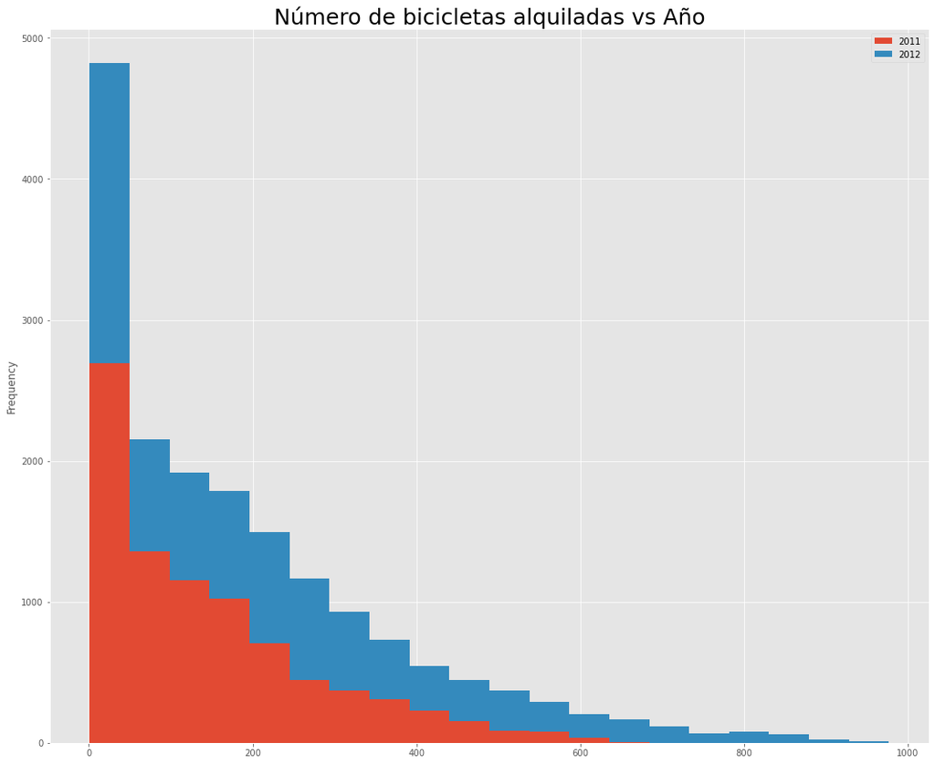

```python
df_2011_2012 = pd.DataFrame({"2011": filtrado_2011["number_of_rentals"],
                             "2012": filtrado_2012["number_of_rentals"]})


df_2011_2012.plot(kind="hist",
                  title="Número de bicicletas alquiladas vs Año",
                  figsize=(18,15),
                  bins = 20,
                  stacked=True)
plt.title("Número de bicicletas alquiladas vs Año", fontsize = 25)
```

Se tiene que en el año 2012 se alquilaron casi el doble de bicis que el anterior 2011. Además, el alquiler de un número de bicis mayor a 651 por día (> 643: outliers!) se produce en su totalidad en el año 2012.

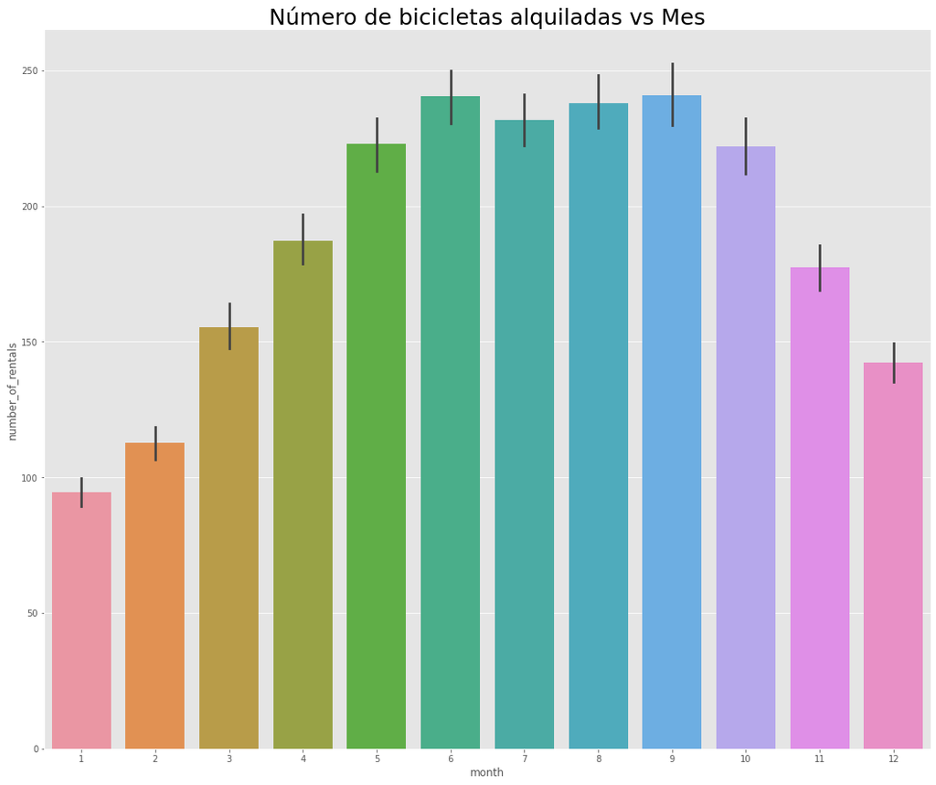

```python
plt.figure(figsize=(18,15))

sns.barplot(x='month',
            y = 'number_of_rentals',
            data=bike_rentals_dataset)

plt.title("Número de bicicletas alquiladas vs Mes", fontsize = 25)
```

Coherencia con lo previamente afirmado respecto a las estaciones del año: los meses de verano y primavera son en los que mayor número de bicicletas se alquilan y los de invierno y otoño en los que menos.

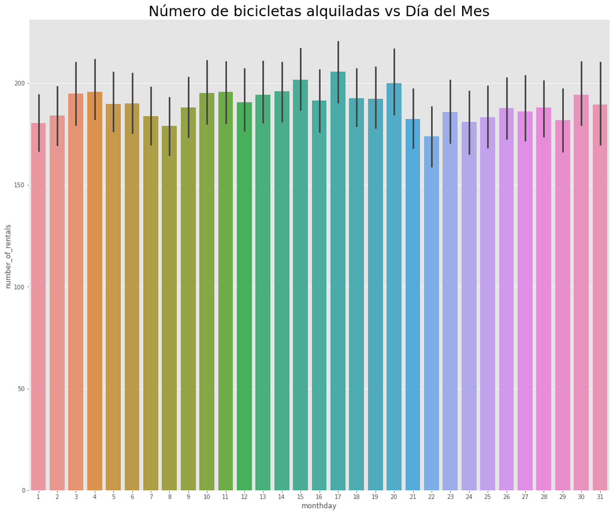

```python
plt.figure(figsize=(18,15))

sns.barplot(x='monthday',
            y = 'number_of_rentals',
            data=bike_rentals_dataset)

plt.title("Número de bicicletas alquiladas vs Día del Mes", fontsize = 25)
```

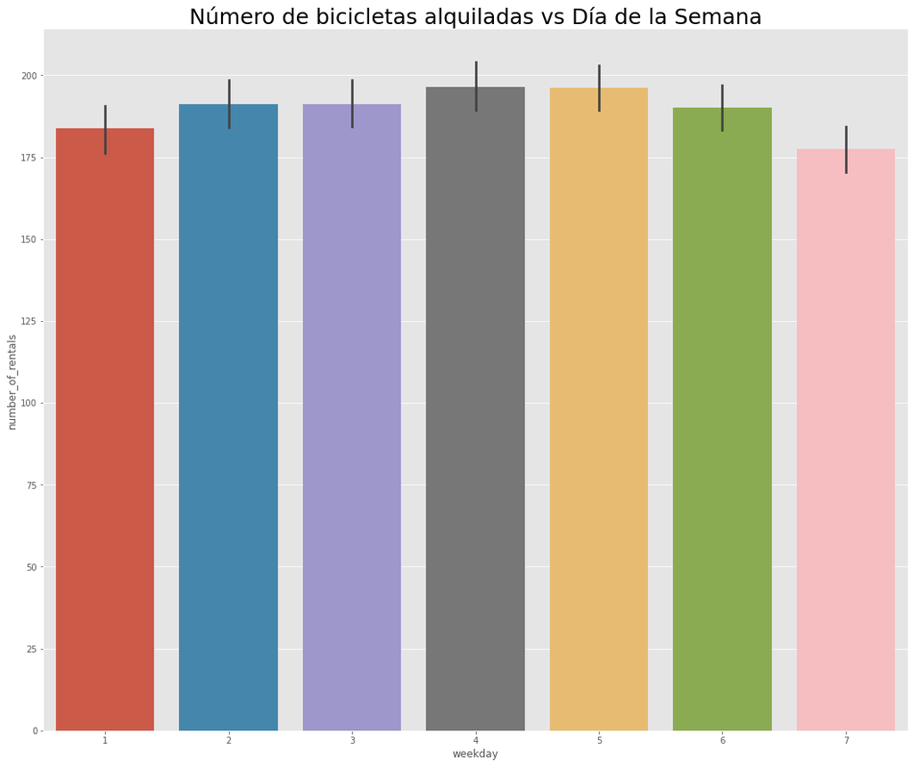

```python
plt.figure(figsize=(18,15))

sns.barplot(x='weekday',
            y = 'number_of_rentals',
            data=bike_rentals_dataset)

plt.title("Número de bicicletas alquiladas vs Día de la Semana", fontsize = 25)
```

Observando el alquiler de bicis en función del día del mes y de la semana de manera conjunta, la semana tiene su punto fuerte en los días centrales subiendo desde los lunes y bajando hacia el domingo. Los días centrales del mes también son en los que más alquileres de bicis se producen.

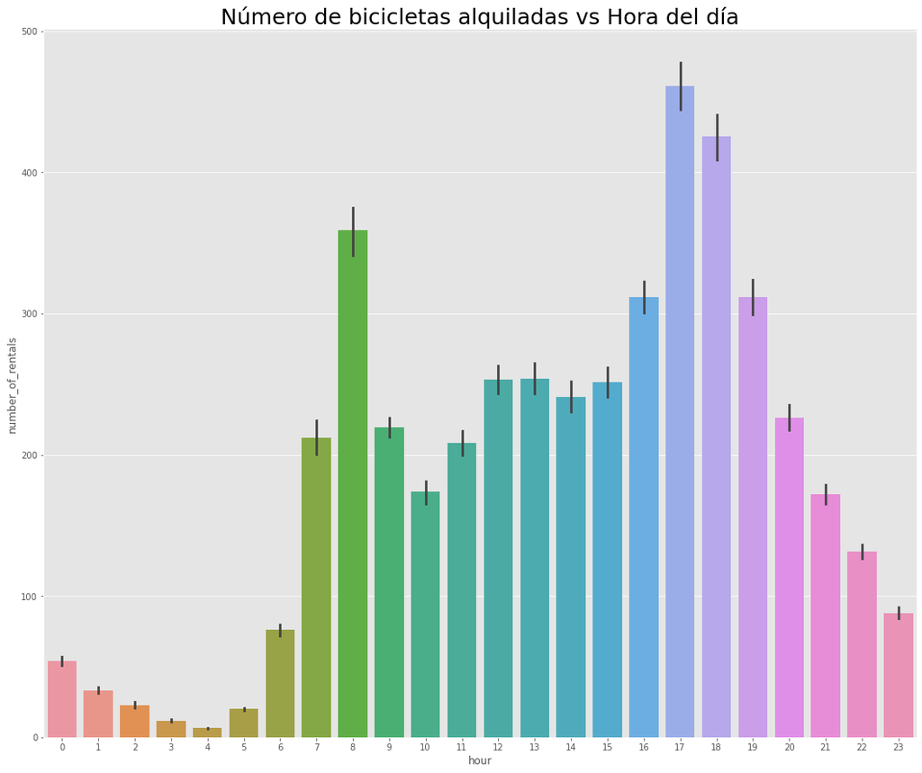

```python
plt.figure(figsize=(18,15))

sns.barplot(x='hour',
            y = 'number_of_rentals',
            data=bike_rentals_dataset)

plt.title("Número de bicicletas alquiladas vs Hora del día", fontsize = 25)
```

Se podría decir que desde la salida del trabajo hasta la hora de la cena se produce el pico de alquiler de bicis (horas de ocio). Después de la cena hasta la hora de levantarse en las que menos. Pico a las 08:00h (antes de entrar al trabajo).

```python
mask = bike_rentals_dataset["holiday"] == 1
filtrado_holiday = bike_rentals_dataset[mask]
filtrado_holiday["number_of_rentals"].sum()
```

```
78435
```

```python
filtrado_holiday["number_of_rentals"].describe()
```

```
count    500.000000
mean     156.870000
std      156.757478
min        1.000000
25%       28.750000
50%       97.000000
75%      253.250000
max      712.000000
Name: number_of_rentals, dtype: float64
```

```python
mask = bike_rentals_dataset["workingday"] == 1
filtrado_workingday = bike_rentals_dataset[mask]
filtrado_workingday["number_of_rentals"].sum()
```

```
2292410
```

```python
filtrado_workingday["number_of_rentals"].describe()
```

```
count    11865.000000
mean       193.207754
std        185.107477
min          1.000000
25%         40.000000
50%        151.000000
75%        277.000000
max        977.000000
Name: number_of_rentals, dtype: float64
```

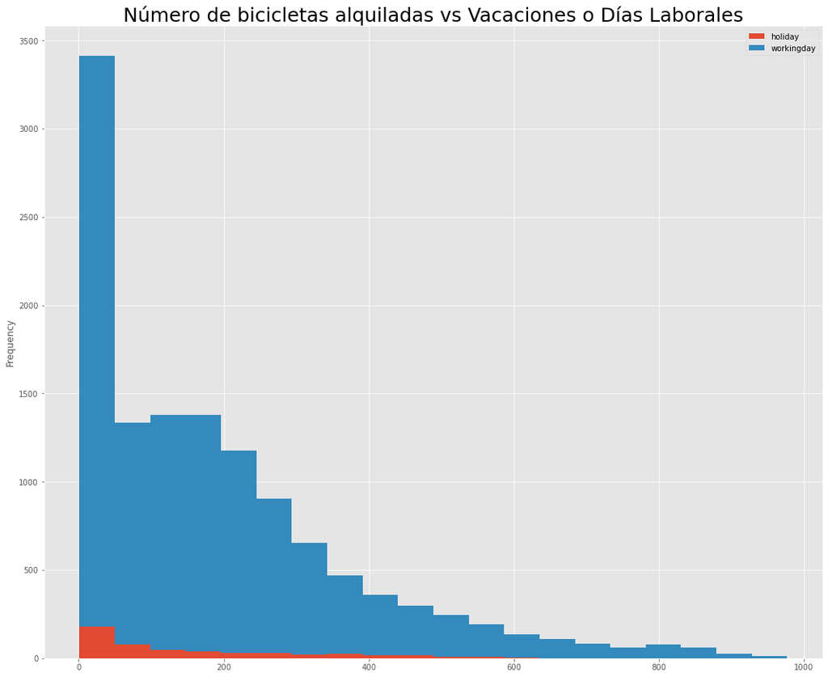

```python
df_holiday_workingday = pd.DataFrame({"holiday": filtrado_holiday["number_of_rentals"],
                                      "workingday": filtrado_workingday["number_of_rentals"]})


df_holiday_workingday.plot(kind="hist",
                           title="Número de bicicletas alquiladas vs Vacaciones o Días Laborales",
                           figsize=(18,15),
                           bins = 20,
                           stacked=True)
plt.title("Número de bicicletas alquiladas vs Vacaciones o Días Laborales", fontsize = 25)
```

Parece que la gente en vacaciones o bien no está muy por alquilar bicis o bien no están en Washington y se han ido a Florida. La diferencia entre ambas es muy significativa.

3.- Features climatológicas: día despejado o poco nuboso, con niebla, lluvias o nieves ligeras, lluvias o nieves fuertes, temperatura, sensación térmica, humedad y velocidad del viento.

'weather**Clear_Fewclouds', 'weather**Mist', 'weather**Light', 'weather**Heavy', 'temperature', 'thermal_sensation', 'humidity', 'windspeed'

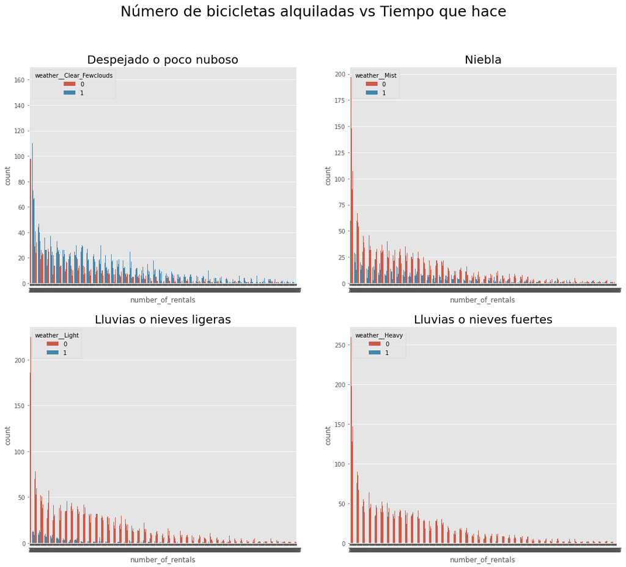

```python
plt.figure(figsize=(18,15))
plt.suptitle("Número de bicicletas alquiladas vs Tiempo que hace", fontsize = 25)

gs = gridspec.GridSpec(2, 2)

plt.subplot(gs[0, 0])
sns.countplot(x='number_of_rentals',
              hue = 'weather__Clear_Fewclouds',
              data=bike_rentals_dataset)
plt.title("Despejado o poco nuboso", fontsize = 20)

plt.subplot(gs[0, 1])
sns.countplot(x='number_of_rentals',
              hue = 'weather__Mist',
              data=bike_rentals_dataset)
plt.title("Niebla", fontsize = 20)


plt.subplot(gs[1, 0])
sns.countplot(x='number_of_rentals',
              hue = 'weather__Light',
              data=bike_rentals_dataset)
plt.title("Lluvias o nieves ligeras", fontsize = 20)


plt.subplot(gs[1, 1])
sns.countplot(x='number_of_rentals',
              hue = 'weather__Heavy',
              data=bike_rentals_dataset)
plt.title("Lluvias o nieves fuertes", fontsize = 20)
```

```python
mask = bike_rentals_dataset["weather__Clear_Fewclouds"] == 1
filtrado_1 = bike_rentals_dataset[mask]
filtrado_1["number_of_rentals"].sum()
```

```
2338173
```

```python
filtrado_1["number_of_rentals"].describe()
```

```
count    11413.000000
mean       204.869272
std        189.487773
min          1.000000
25%         46.000000
50%        159.000000
75%        304.000000
max        977.000000
Name: number_of_rentals, dtype: float64
```

```python
mask = bike_rentals_dataset["weather__Mist"] == 1
filtrado_1 = bike_rentals_dataset[mask]
filtrado_1["number_of_rentals"].sum()
```

```
795952
```

```python
filtrado_1["number_of_rentals"].describe()
```

```
count    4544.000000
mean      175.165493
std       165.431589
min         1.000000
25%        40.000000
50%       133.000000
75%       257.000000
max       957.000000
Name: number_of_rentals, dtype: float64
```

```python
mask = bike_rentals_dataset["weather__Light"] == 1
filtrado_1 = bike_rentals_dataset[mask]
filtrado_1["number_of_rentals"].sum()
```

```
158331
```

```python
filtrado_1["number_of_rentals"].describe()
```

```
count    1419.000000
mean      111.579281
std       133.781045
min         1.000000
25%        21.000000
50%        63.000000
75%       152.500000
max       891.000000
Name: number_of_rentals, dtype: float64
```

```python
mask = bike_rentals_dataset["weather__Heavy"] == 1
filtrado_1 = bike_rentals_dataset[mask]
filtrado_1["number_of_rentals"].sum()
```

```
223
```

```python
filtrado_1["number_of_rentals"].describe()
```

```
count      3.000000
mean      74.333333
std       77.925178
min       23.000000
25%       29.500000
50%       36.000000
75%      100.000000
max      164.000000
Name: number_of_rentals, dtype: float64
```

De la primera gráfica ya se puede extraer que para un tiempo despejado o poco nuboso se realizan más alquileres de bicis que para el conjunto de los otros tres: niebla, lluvia o nieve ya sean éstas ligeras o fuertes. Practicamente no se realizan alquileres de bicis con tiempo de lluvia o nieve fuerte. Con niebla la gente se anima cinco veces más a alquilar bicis que cuando hay lluvia o nieve ligeras.

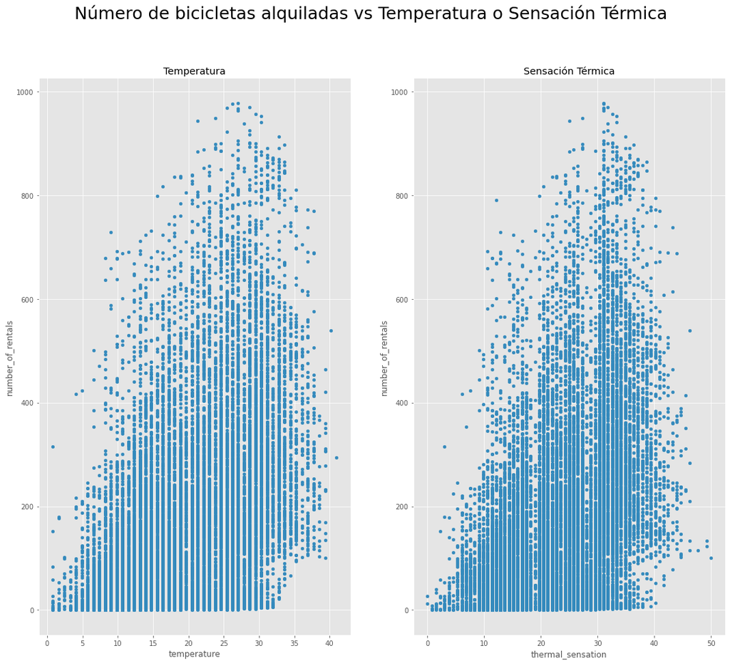

```python
plt.figure(figsize=(18,15))
plt.suptitle("Número de bicicletas alquiladas vs Temperatura o Sensación Térmica", fontsize = 25)


axes1=plt.subplot(1,2,1, title="Temperatura")
bike_rentals_dataset.plot.scatter(x="temperature",y="number_of_rentals",ax=axes1)

axes2=plt.subplot(1,2,2, title="Sensación Térmica")
bike_rentals_dataset.plot.scatter(x="thermal_sensation",y="number_of_rentals",ax=axes2)
```

Parece que la tendencia sería que a más temperatura la gente se anima más a alquilar bicis. Con temperaturas bajas y a partir de una cierta alta temperatura de en torno a 35ºC o sensación térmica de 40ºC se producen menos alquileres de bicis.

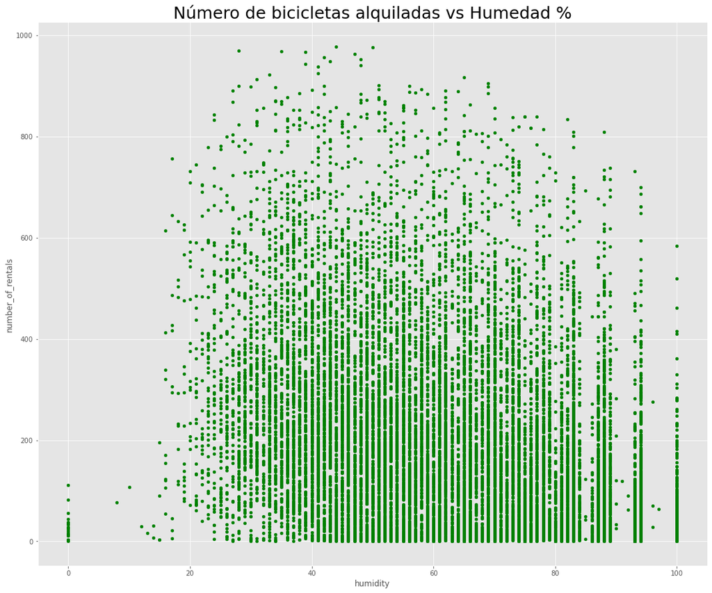

```python
bike_rentals_dataset.plot.scatter(x="humidity",y="number_of_rentals",
                                  figsize=(18,15),
                                  color="green")
plt.title("Número de bicicletas alquiladas vs Humedad %", fontsize = 25)
```

Un ambiente agradable debe tener una humedad relativa de 40-60% y se considera aceptable entre un 30% y un 70%. En este caso el grueso se encuentra entre 35% y 85%. Es posible que al ser Washington una ciudad costera la tolerancia a humedades relativas altas sea mayor o puedan coincidir con periodos de playa-costa-bici.

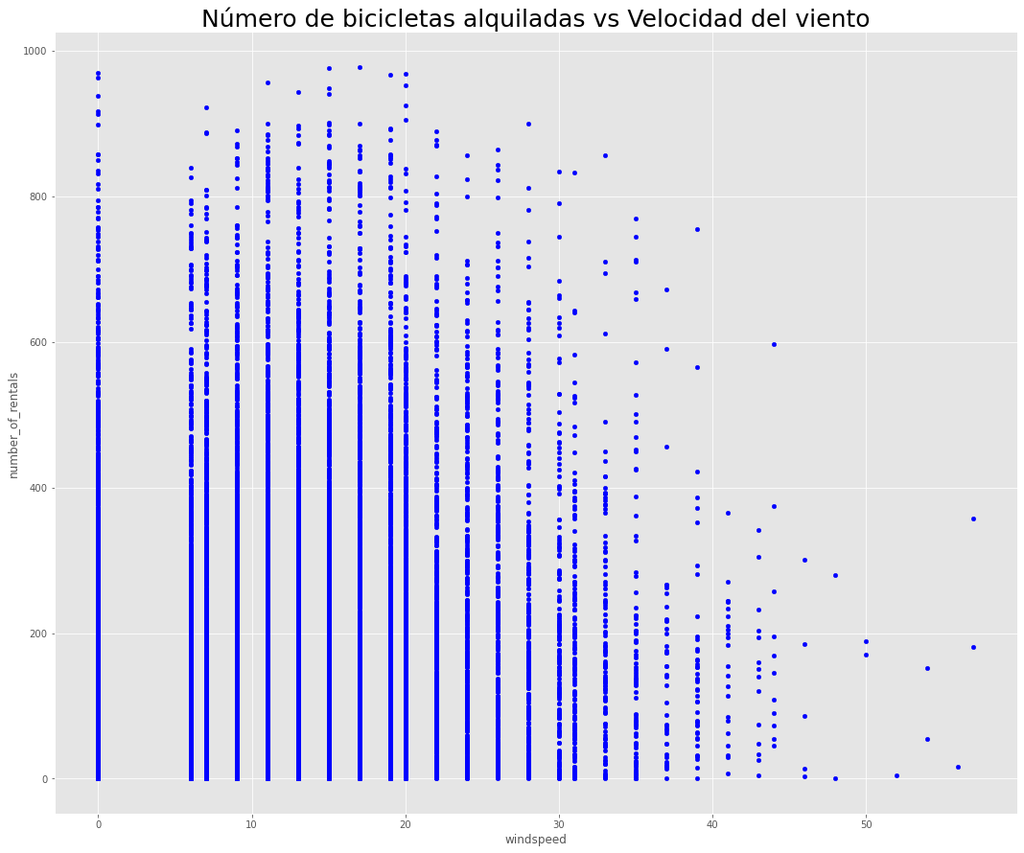

```python
bike_rentals_dataset.plot.scatter(x="windspeed",y="number_of_rentals",
                                  figsize=(18,15),
                                  color="blue")
plt.title("Número de bicicletas alquiladas vs Velocidad del viento", fontsize = 25)
```

Se observa que para valores bajos de velocidad del viento, de hasta alrededor de 20 mmph, se tienen los mayores números de alquileres de bicis. A partir de ahí, es decir, para valores moderados-altos de velocidad del viento el número de alquileres de bicis baja.

Matriz de correlación: se comienza con un primer acercamiento numérico para su análisis y se continua con un posterior acercameinto visual:

```python
bike_rentals_dataset[features].corr()
```

|  | season__spring | season__summer | season__autumn | season__winter | year | month | monthday | hour | weekday | holiday | workingday | weather__Clear_Fewclouds | weather__Mist | weather__Light | weather__Heavy | temperature | thermal_sensation | humidity | windspeed |
| --- | --- | --- | --- | --- | --- | --- | --- | --- | --- | --- | --- | --- | --- | --- | --- | --- | --- | --- | --- |
| season__spring | 1.000000 | -0.344433 | -0.330795 | -0.331312 | -0.002589 | -0.319382 | 0.010003 | -0.002919 | -0.008950 | -0.024404 | 0.015879 | -0.010150 | -0.002648 | 0.022216 | -0.007661 | 0.144363 | 0.151903 | -0.000625 | 0.063447 |
| season__summer | -0.344433 | 1.000000 | -0.335169 | -0.335693 | -0.000923 | 0.197900 | 0.016495 | -0.003348 | -0.005217 | -0.026216 | 0.020182 | 0.090609 | -0.068338 | -0.047072 | -0.007762 | 0.642516 | 0.619570 | 0.018184 | -0.089358 |
| season__autumn | -0.330795 | -0.335169 | 1.000000 | -0.322401 | -0.007732 | 0.687155 | -0.017224 | -0.001994 | 0.000170 | 0.017840 | -0.007280 | -0.048059 | 0.043164 | 0.014421 | -0.007455 | -0.217601 | -0.198218 | 0.117326 | -0.089410 |
| season__winter | -0.331312 | -0.335693 | -0.322401 | 1.000000 | 0.011290 | -0.564834 | -0.009740 | 0.008363 | 0.014214 | 0.033622 | -0.029387 | -0.034074 | 0.029224 | 0.011075 | 0.023123 | -0.583859 | -0.587470 | -0.135138 | 0.116168 |
| year | -0.002589 | -0.000923 | -0.007732 | 0.011290 | 1.000000 | -0.010473 | 0.002057 | -0.003867 | 0.000977 | 0.006692 | -0.002196 | 0.007823 | 0.011095 | -0.031576 | 0.004313 | 0.040913 | 0.039222 | -0.083546 | -0.008740 |
| month | -0.319382 | 0.197900 | 0.687155 | -0.564834 | -0.010473 | 1.000000 | 0.007929 | -0.005772 | 0.003017 | 0.018430 | -0.003477 | -0.010419 | 0.014027 | -0.003428 | -0.021161 | 0.201691 | 0.208096 | 0.164411 | -0.135386 |
| monthday | 0.010003 | 0.016495 | -0.017224 | -0.009740 | 0.002057 | 0.007929 | 1.000000 | 0.001538 | -0.006845 | -0.010132 | 0.008627 | 0.004691 | -0.004357 | -0.001357 | 0.004460 | 0.027180 | 0.021269 | 0.025663 | 0.010505 |
| hour | -0.002919 | -0.003348 | -0.001994 | 0.008363 | -0.003867 | -0.005772 | 0.001538 | 1.000000 | -0.002893 | 0.000479 | 0.002285 | 0.036999 | -0.050555 | 0.016963 | 0.000228 | 0.137603 | 0.133750 | -0.276498 | 0.137252 |
| weekday | -0.008950 | -0.005217 | 0.000170 | 0.014214 | 0.000977 | 0.003017 | -0.006845 | -0.002893 | 1.000000 | -0.188924 | -0.702419 | 0.048508 | -0.037416 | -0.023853 | -0.004451 | -0.036220 | -0.038918 | -0.035233 | 0.003274 |
| holiday | -0.024404 | -0.026216 | 0.017840 | 0.033622 | 0.006692 | 0.018430 | -0.010132 | 0.000479 | -0.188924 | 1.000000 | -0.252471 | 0.009167 | 0.004910 | -0.023664 | -0.002262 | -0.027340 | -0.030973 | -0.010588 | 0.003988 |
| workingday | 0.015879 | 0.020182 | -0.007280 | -0.029387 | -0.002196 | -0.003477 | 0.008627 | 0.002285 | -0.702419 | -0.252471 | 1.000000 | -0.041633 | 0.024960 | 0.032155 | -0.000453 | 0.055390 | 0.054667 | 0.015688 | -0.011830 |
| weather__Clear_Fewclouds | -0.010150 | 0.090609 | -0.048059 | -0.034074 | 0.007823 | -0.010419 | 0.004691 | 0.036999 | 0.048508 | 0.009167 | -0.041633 | 1.000000 | -0.822961 | -0.412414 | -0.018174 | 0.101044 | 0.101504 | -0.383425 | 0.005150 |
| weather__Mist | -0.002648 | -0.068338 | 0.043164 | 0.029224 | 0.011095 | 0.014027 | -0.004357 | -0.050555 | -0.037416 | 0.004910 | 0.024960 | -0.822961 | 1.000000 | -0.177417 | -0.007818 | -0.069657 | -0.066425 | 0.220758 | -0.049241 |
| weather__Light | 0.022216 | -0.047072 | 0.014421 | 0.011075 | -0.031576 | -0.003428 | -0.001357 | 0.016963 | -0.023853 | -0.023664 | 0.032155 | -0.412414 | -0.177417 | 1.000000 | -0.003918 | -0.062406 | -0.068346 | 0.309737 | 0.070018 |
| weather__Heavy | -0.007661 | -0.007762 | -0.007455 | 0.023123 | 0.004313 | -0.021161 | 0.004460 | 0.000228 | -0.004451 | -0.002262 | -0.000453 | -0.018174 | -0.007818 | -0.003918 | 1.000000 | -0.021176 | -0.022088 | 0.017443 | 0.001493 |
| temperature | 0.144363 | 0.642516 | -0.217601 | -0.583859 | 0.040913 | 0.201691 | 0.027180 | 0.137603 | -0.036220 | -0.027340 | 0.055390 | 0.101044 | -0.069657 | -0.062406 | -0.021176 | 1.000000 | 0.987672 | -0.069881 | -0.023125 |
| thermal_sensation | 0.151903 | 0.619570 | -0.198218 | -0.587470 | 0.039222 | 0.208096 | 0.021269 | 0.133750 | -0.038918 | -0.030973 | 0.054667 | 0.101504 | -0.066425 | -0.068346 | -0.022088 | 0.987672 | 1.000000 | -0.051918 | -0.062336 |
| humidity | -0.000625 | 0.018184 | 0.117326 | -0.135138 | -0.083546 | 0.164411 | 0.025663 | -0.276498 | -0.035233 | -0.010588 | 0.015688 | -0.383425 | 0.220758 | 0.309737 | 0.017443 | -0.069881 | -0.051918 | 1.000000 | -0.290105 |
| windspeed | 0.063447 | -0.089358 | -0.089410 | 0.116168 | -0.008740 | -0.135386 | 0.010505 | 0.137252 | 0.003274 | 0.003988 | -0.011830 | 0.005150 | -0.049241 | 0.070018 | 0.001493 | -0.023125 | -0.062336 | -0.290105 | 1.000000 |

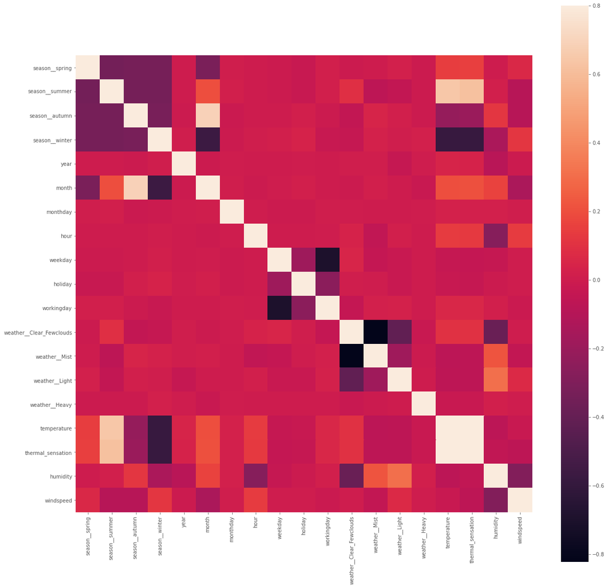

```python
corrmat = bike_rentals_dataset[features].corr()
f, ax = plt.subplots(figsize=(20, 20))
sns.heatmap(corrmat, vmax=.8, square=True)
```

El mapa de calor es una forma visual muy útil para conocer las variables y sus relaciones. A primera vista hay diversas variables que llaman la atención: 'season_winter' vs 'temperature' & 'thermal_sensation', 'weekday' vs 'workingday', 'weather**Clear_Fewclouds' vs 'weather**Mist' y 'temperature' vs 'thermal_sensation'. En estos casos parece haber una correlación significativa (positiva o negativa). En realidad son tan fuertes que podrían indicar multicolinealidad, es decir, que básicamente podrían ofrecer la misma información.

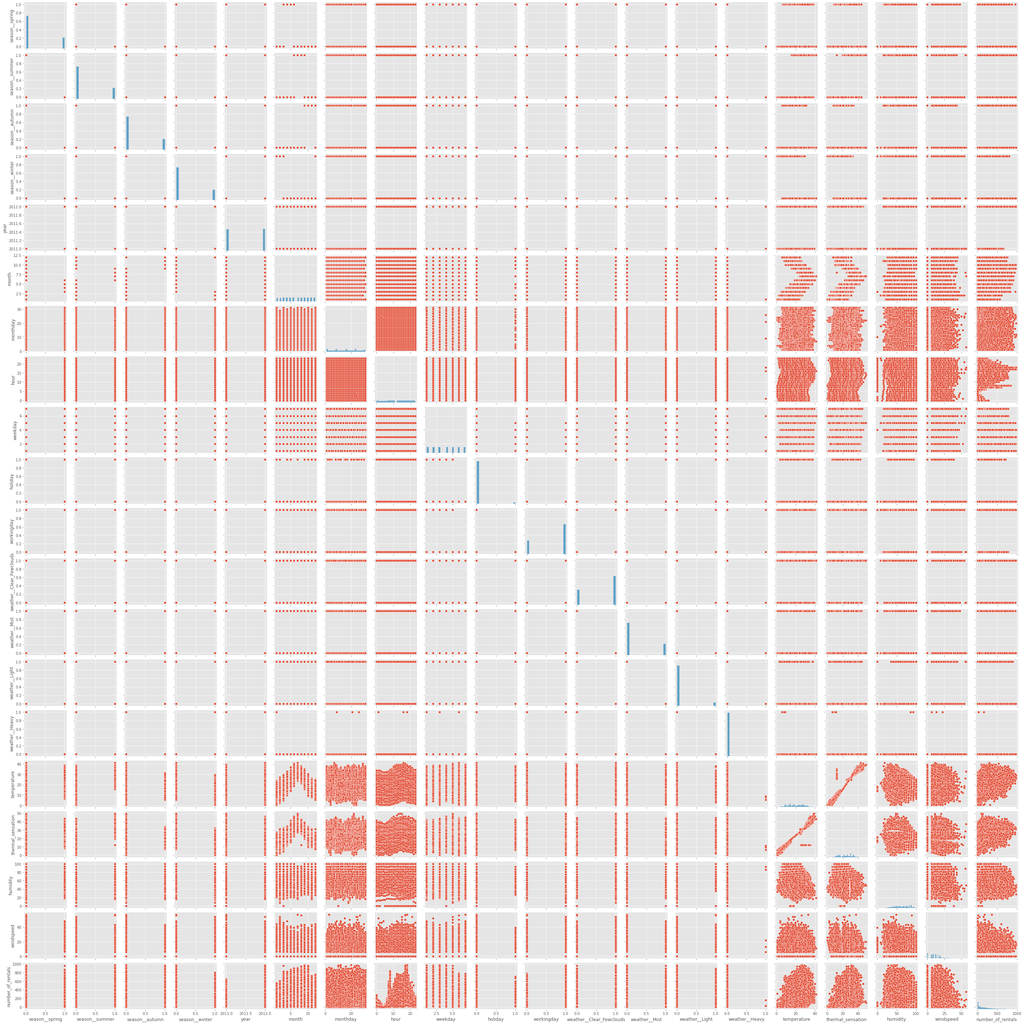

```python
sns.pairplot(bike_rentals_dataset, height = 2, diag_kind = "hist")
```

Se ha realizado un pairplot aunque en este caso no aporte mucho. Toda la información relevante referente a variables ya se ha ido obteniendo hasta ahora.

# 3. Separación en train y test

Dado que las observaciones en este dataset tienen un cierto orden cronológico, se separa un conjunto de test de la siguiente forma: el conjunto de test deberá contener únicamente las observaciones desde el 1 de junio de 2012 en adelante, es decir, del 2012-06-01 al 2012-12-31 ambos incluidos. Dado que estas observaciones son los 7 meses más recientes de los que se tienen datos, es buena praxis hacerlo de esta manera, ya que de este modo, el conjunto de test será una representación lo más fiel y reciente posible de los datos que lleguen en el futuro.

Se tendrán por lo tanto porcentajes del 70.83% de los valores para uso de entrenamiento y validación del modelo y del 29.17% para su posterior testeo.

```python
mask_test_paso_1 = bike_rentals_dataset["year"] == 2012
test = bike_rentals_dataset[mask_test_paso_1]

mask_test_paso_2 = test["month"] >= 6
test = test[mask_test_paso_2]
```

```python
test
```

|  | season__spring | season__summer | season__autumn | season__winter | year | month | monthday | hour | weekday | holiday | workingday | weather__Clear_Fewclouds | weather__Mist | weather__Light | weather__Heavy | temperature | humidity | windspeed | number_of_rentals |
| --- | --- | --- | --- | --- | --- | --- | --- | --- | --- | --- | --- | --- | --- | --- | --- | --- | --- | --- | --- |
| 12283 | 1 | 0 | 0 | 0 | 2012 | 6 | 1 | 0 | 5 | 0 | 1 | 1 | 0 | 0 | 0 | 27.06 | 50.0 | 16.9979 | 86 |
| 12284 | 1 | 0 | 0 | 0 | 2012 | 6 | 1 | 1 | 5 | 0 | 1 | 1 | 0 | 0 | 0 | 26.24 | 53.0 | 15.0013 | 34 |
| 12285 | 1 | 0 | 0 | 0 | 2012 | 6 | 1 | 2 | 5 | 0 | 1 | 1 | 0 | 0 | 0 | 26.24 | 57.0 | 15.0013 | 16 |
| 12286 | 1 | 0 | 0 | 0 | 2012 | 6 | 1 | 3 | 5 | 0 | 1 | 0 | 1 | 0 | 0 | 25.42 | 73.0 | 6.0032 | 4 |
| 12287 | 1 | 0 | 0 | 0 | 2012 | 6 | 1 | 4 | 5 | 0 | 1 | 0 | 1 | 0 | 0 | 25.42 | 73.0 | 6.0032 | 6 |
| ... | ... | ... | ... | ... | ... | ... | ... | ... | ... | ... | ... | ... | ... | ... | ... | ... | ... | ... | ... |
| 17374 | 0 | 0 | 0 | 1 | 2012 | 12 | 31 | 19 | 1 | 0 | 1 | 0 | 1 | 0 | 0 | 10.66 | 60.0 | 11.0014 | 119 |
| 17375 | 0 | 0 | 0 | 1 | 2012 | 12 | 31 | 20 | 1 | 0 | 1 | 0 | 1 | 0 | 0 | 10.66 | 60.0 | 11.0014 | 89 |
| 17376 | 0 | 0 | 0 | 1 | 2012 | 12 | 31 | 21 | 1 | 0 | 1 | 1 | 0 | 0 | 0 | 10.66 | 60.0 | 11.0014 | 90 |
| 17377 | 0 | 0 | 0 | 1 | 2012 | 12 | 31 | 22 | 1 | 0 | 1 | 1 | 0 | 0 | 0 | 10.66 | 56.0 | 8.9981 | 61 |
| 17378 | 0 | 0 | 0 | 1 | 2012 | 12 | 31 | 23 | 1 | 0 | 1 | 1 | 0 | 0 | 0 | 10.66 | 65.0 | 8.9981 | 49 |

5096 rows × 19 columns

```python
train_y_val = bike_rentals_dataset[0:12283]
```

```python
train_y_val
```

|  | season__spring | season__summer | season__autumn | season__winter | year | month | monthday | hour | weekday | holiday | workingday | weather__Clear_Fewclouds | weather__Mist | weather__Light | weather__Heavy | temperature | humidity | windspeed | number_of_rentals |
| --- | --- | --- | --- | --- | --- | --- | --- | --- | --- | --- | --- | --- | --- | --- | --- | --- | --- | --- | --- |
| 0 | 0 | 0 | 0 | 1 | 2011 | 1 | 1 | 0 | 6 | 0 | 0 | 1 | 0 | 0 | 0 | 9.84 | 81.0 | 0.0000 | 16 |
| 1 | 0 | 0 | 0 | 1 | 2011 | 1 | 1 | 1 | 6 | 0 | 0 | 1 | 0 | 0 | 0 | 9.02 | 80.0 | 0.0000 | 40 |
| 2 | 0 | 0 | 0 | 1 | 2011 | 1 | 1 | 2 | 6 | 0 | 0 | 1 | 0 | 0 | 0 | 9.02 | 80.0 | 0.0000 | 32 |
| 3 | 0 | 0 | 0 | 1 | 2011 | 1 | 1 | 3 | 6 | 0 | 0 | 1 | 0 | 0 | 0 | 9.84 | 75.0 | 0.0000 | 13 |
| 4 | 0 | 0 | 0 | 1 | 2011 | 1 | 1 | 4 | 6 | 0 | 0 | 1 | 0 | 0 | 0 | 9.84 | 75.0 | 0.0000 | 1 |
| ... | ... | ... | ... | ... | ... | ... | ... | ... | ... | ... | ... | ... | ... | ... | ... | ... | ... | ... | ... |
| 12278 | 1 | 0 | 0 | 0 | 2012 | 5 | 31 | 19 | 4 | 0 | 1 | 1 | 0 | 0 | 0 | 29.52 | 34.0 | 11.0014 | 591 |
| 12279 | 1 | 0 | 0 | 0 | 2012 | 5 | 31 | 20 | 4 | 0 | 1 | 1 | 0 | 0 | 0 | 27.88 | 44.0 | 11.0014 | 479 |
| 12280 | 1 | 0 | 0 | 0 | 2012 | 5 | 31 | 21 | 4 | 0 | 1 | 1 | 0 | 0 | 0 | 27.88 | 44.0 | 11.0014 | 359 |
| 12281 | 1 | 0 | 0 | 0 | 2012 | 5 | 31 | 22 | 4 | 0 | 1 | 1 | 0 | 0 | 0 | 27.06 | 50.0 | 11.0014 | 264 |
| 12282 | 1 | 0 | 0 | 0 | 2012 | 5 | 31 | 23 | 4 | 0 | 1 | 1 | 0 | 0 | 0 | 27.06 | 54.0 | 15.0013 | 140 |

12283 rows × 19 columns

# 4. Preprocesado del conjunto de train

Antes de realizar modelos o validaciones cruzadas se deben plantear una serie de decisiones sobre los datos:

1.- ¿Descartar variables directamente por alta correlación? Se toma como premisa de trabajo no eliminar variables por alta correlación.

2.- ¿Quitar outliers? Se toma como premisa de trabajo no eliminar ouliers.

3.- ¿Estandarizar las features? Sí se realizará.

4.- ¿Seleccionar features / hacer reducción de dimensionalidad? Sí se realizará la selección de features pero al tener 19 variables no tiene sentido realizar una reducción de dimensionalidad.

Llegados a este punto, a partir de ahora el objetivo es probar un gran número de combinaciones de modelos de regresión e hiperparámetros.

# 5. Regresiones

## 5.1. Regresión lineal simple (mínimos cuadrados ordinarios)

```python
from sklearn.linear_model import LinearRegression

ols = LinearRegression(fit_intercept=True)
```

```python
ols.fit(train_y_val[features], train_y_val["number_of_rentals"])
```

```
LinearRegression()
```

```python
print("beta0 o intercept: " + str(ols.intercept_))
print("beta1_19: " + str(ols.coef_[:]))
```

```
beta0 o intercept: -158029.5036947793
beta1_19: [  7.63708378 -26.71730484  31.04770103 -11.96747996  78.57686884
   1.64854206  -0.11661987   6.46893533   1.45943345 -20.45836713
   4.06121732  -2.77506851   3.0994456  -32.59464537  32.27026827
   4.74237697   2.92856357  -1.53927904   0.20916327]
```

```python
print("R cuadrado : " + str(ols.score(test[features], test["number_of_rentals"])))
```

```
R cuadrado : 0.3072819976083053
```

El R cuadrado o coeficiente de determinación no es recomendable como medida del rendimiento de regresión. Se recomienda utilizar otro tipo de métricas, como puede ser el error cuadrático medio: mean squared error o MSE, o bien la raíz de este valor: root mean squared error o RMSE.

```python
from sklearn.metrics import mean_squared_error

mse = mean_squared_error(y_true=test["number_of_rentals"], y_pred=ols.predict(test[features]))

rmse = np.sqrt(mse)

print("MSE: " + str(mse))
print("RMSE ols test: " +  str(rmse))
```

```
MSE: 33608.770969750534
RMSE ols test: 183.3269510185301
```

El RMSE se puede entender como: en términos medios, se falla en las predicciones por unas 183 de bicis alquiladas esa hora, ya sea de más o de menos, sobre el valor real.

Para poder comparar todos los modelos de igual manera es importante establecer una Cross Validation idéntica para todos, con una misma semilla aleatoria.

```python
from sklearn.model_selection import KFold

# CrossValidation: se consideran 10 experimentos adecuados.

config_cross_validation = KFold(10, shuffle = True, random_state = 777)
```

```python
from sklearn.model_selection import cross_val_score

linear_regression = LinearRegression(fit_intercept=True)

mse = cross_val_score(linear_regression,
                     train_y_val[features], train_y_val["number_of_rentals"],
                     cv=config_cross_validation,
                     scoring="neg_mean_squared_error",
                     verbose=1,
                     n_jobs=-1)

mean_mse = np.mean(mse)
rmse_linear_regression = round(np.sqrt(abs(mean_mse)), 2)
print("RMSE linear_regression: " +  str(rmse_linear_regression))
```

```
[Parallel(n_jobs=-1)]: Using backend LokyBackend with 8 concurrent workers.
```

```
RMSE linear_regression: 120.01
```

```
[Parallel(n_jobs=-1)]: Done   6 out of  10 | elapsed:    4.3s remaining:    2.8s
[Parallel(n_jobs=-1)]: Done  10 out of  10 | elapsed:    4.3s finished
```

## 5.2. Regularización: Ridge, LASSO y Elastic Net

### 5.2.1 Regresión Ridge

```python
from sklearn.pipeline import Pipeline
from sklearn.preprocessing import StandardScaler
from sklearn.model_selection import GridSearchCV

from sklearn.linear_model import Ridge

# Creación de Pipeline
ridge = Pipeline(steps=[("scaler",StandardScaler()),
                        ("rid",Ridge())
                       ]
                )

# Grid de hiperparámetros
grid_ridge = {"rid__alpha" : [1e-15, 1e-10, 1e-8, 1e-3, 1e-2, 0.05, 0.1, 0.5, 1, 5, 10, 20, 50, 100],
              "rid__fit_intercept" : [True]
             }

# Grid Search y selección del modelo
gs_ridge = GridSearchCV(ridge,
                        grid_ridge,
                        cv=config_cross_validation,
                        scoring="neg_mean_squared_error",
                        verbose=1,
                        n_jobs=-1)

# Entrenamiento del modelo
gs_ridge.fit(train_y_val[features], train_y_val["number_of_rentals"])

# Resultado obtenido del modelo
print(gs_ridge.best_params_)
print(gs_ridge.best_score_)
rmse_ridge = round(np.sqrt(abs(gs_ridge.best_score_)), 2)
print("RMSE ridge: " +  str(rmse_ridge))
```

```
Fitting 10 folds for each of 14 candidates, totalling 140 fits
```

```
[Parallel(n_jobs=-1)]: Using backend LokyBackend with 8 concurrent workers.
[Parallel(n_jobs=-1)]: Done  56 tasks      | elapsed:    0.6s
[Parallel(n_jobs=-1)]: Done 140 out of 140 | elapsed:    1.0s finished
```

```
{'rid__alpha': 100, 'rid__fit_intercept': True}
-14401.761846025183
RMSE ridge: 120.01
```

### 5.2.2 Regresión Lasso

```python
from sklearn.linear_model import Lasso

# Creación de Pipeline
lasso = Pipeline(steps=[("scaler",StandardScaler()),
                        ("las",Lasso())
                       ]
                )

# Grid de hiperparámetros
grid_lasso = {"las__alpha" : [1e-15, 1e-10, 1e-8, 1e-3, 1e-2, 0.05, 0.1, 0.5, 1, 5, 10, 20, 50, 100],
              "las__fit_intercept" : [True]
             }

# Grid Search y selección del modelo
gs_lasso = GridSearchCV(lasso,
                        grid_lasso,
                        cv=config_cross_validation,
                        scoring="neg_mean_squared_error",
                        verbose=1,
                        n_jobs=-1)

# Entrenamiento del modelo
gs_lasso.fit(train_y_val[features], train_y_val["number_of_rentals"])

# Resultado obtenido del modelo
print(gs_lasso.best_params_)
print(gs_lasso.best_score_)
rmse_lasso = round(np.sqrt(abs(gs_lasso.best_score_)), 2)
print("RMSE lasso: " +  str(rmse_lasso))
```

```
Fitting 10 folds for each of 14 candidates, totalling 140 fits
```

```
[Parallel(n_jobs=-1)]: Using backend LokyBackend with 8 concurrent workers.
[Parallel(n_jobs=-1)]: Done  34 tasks      | elapsed:    4.3s
```

```
{'las__alpha': 0.01, 'las__fit_intercept': True}
-14403.203664597677
RMSE lasso: 120.01
```

```
[Parallel(n_jobs=-1)]: Done 140 out of 140 | elapsed:    7.8s finished
```

### 5.2.3 Regresión Elastic Net

```python
from sklearn.linear_model import ElasticNet

# Creación de Pipeline
elastic_net = Pipeline(steps=[("scaler",StandardScaler()),
                              ("elast",ElasticNet())
                             ]
                      )

# Grid de hiperparámetros
grid_elastic_net = {"elast__l1_ratio" : [0, 0.1, 0.5, 0.7, 0.9, 0.95, 0.99],
                    "elast__alpha" : [1e-15, 1e-10, 1e-8, 1e-3, 1e-2, 0.05, 0.1, 0.5, 1, 5, 10, 20, 50, 100]
                   }

# Grid Search y selección del modelo
gs_elastic_net = GridSearchCV(elastic_net,
                              grid_elastic_net,
                              cv=config_cross_validation,
                              scoring="neg_mean_squared_error",
                              verbose=1,
                              n_jobs=-1)

# Entrenamiento del modelo
gs_elastic_net.fit(train_y_val[features], train_y_val["number_of_rentals"])

# Resultado obtenido del modelo
print(gs_elastic_net.best_params_)
print(gs_elastic_net.best_score_)
rmse_elastic_net = round(np.sqrt(abs(gs_elastic_net.best_score_)), 2)
print("RMSE elastic_net: " +  str(rmse_elastic_net))
```

```
Fitting 10 folds for each of 98 candidates, totalling 980 fits
```

```
[Parallel(n_jobs=-1)]: Using backend LokyBackend with 8 concurrent workers.
[Parallel(n_jobs=-1)]: Done  34 tasks      | elapsed:    4.6s
[Parallel(n_jobs=-1)]: Done 184 tasks      | elapsed:   22.8s
[Parallel(n_jobs=-1)]: Done 434 tasks      | elapsed:   43.3s
[Parallel(n_jobs=-1)]: Done 980 out of 980 | elapsed:   58.3s finished
```

```
{'elast__alpha': 0.01, 'elast__l1_ratio': 0}
-14401.764378599943
RMSE elastic_net: 120.01
```

## 5.3. Regresión polinómica: transformación no lineal del dataset

```python
from sklearn.preprocessing import PolynomialFeatures

poly = PolynomialFeatures(degree=3,
                          interaction_only=True,
                          include_bias=True)

features_poly = poly.fit_transform(train_y_val[features])
```

```python
features_poly
```

```
array([[1.00000000e+00, 0.00000000e+00, 0.00000000e+00, ...,
        0.00000000e+00, 0.00000000e+00, 0.00000000e+00],
       [1.00000000e+00, 0.00000000e+00, 0.00000000e+00, ...,
        0.00000000e+00, 0.00000000e+00, 0.00000000e+00],
       [1.00000000e+00, 0.00000000e+00, 0.00000000e+00, ...,
        0.00000000e+00, 0.00000000e+00, 0.00000000e+00],
       ...,
       [1.00000000e+00, 1.00000000e+00, 0.00000000e+00, ...,
        9.75979960e+03, 1.34956374e+04, 1.54028401e+04],
       [1.00000000e+00, 1.00000000e+00, 0.00000000e+00, ...,
        9.24649628e+03, 1.48848942e+04, 1.70851742e+04],
       [1.00000000e+00, 1.00000000e+00, 0.00000000e+00, ...,
        1.26083466e+04, 2.19204996e+04, 2.51607804e+04]])
```

```python
poly_train_y_val = pd.DataFrame(features_poly)

poly_train_y_val["number_of_rentals"] = np.array(train_y_val["number_of_rentals"])
```

```python
poly_train_y_val
```

|  | 0 | 1 | 2 | 3 | 4 | 5 | 6 | 7 | 8 | 9 | ... | 1151 | 1152 | 1153 | 1154 | 1155 | 1156 | 1157 | 1158 | 1159 | number_of_rentals |
| --- | --- | --- | --- | --- | --- | --- | --- | --- | --- | --- | --- | --- | --- | --- | --- | --- | --- | --- | --- | --- | --- |
| 0 | 1.0 | 0.0 | 0.0 | 0.0 | 1.0 | 2011.0 | 1.0 | 1.0 | 0.0 | 6.0 | ... | 0.0 | 0.0 | 0.0 | 0.0 | 0.0 | 11473.3908 | 0.000000 | 0.000000 | 0.000000 | 16 |
| 1 | 1.0 | 0.0 | 0.0 | 0.0 | 1.0 | 2011.0 | 1.0 | 1.0 | 1.0 | 6.0 | ... | 0.0 | 0.0 | 0.0 | 0.0 | 0.0 | 9839.0160 | 0.000000 | 0.000000 | 0.000000 | 40 |
| 2 | 1.0 | 0.0 | 0.0 | 0.0 | 1.0 | 2011.0 | 1.0 | 1.0 | 2.0 | 6.0 | ... | 0.0 | 0.0 | 0.0 | 0.0 | 0.0 | 9839.0160 | 0.000000 | 0.000000 | 0.000000 | 32 |
| 3 | 1.0 | 0.0 | 0.0 | 0.0 | 1.0 | 2011.0 | 1.0 | 1.0 | 3.0 | 6.0 | ... | 0.0 | 0.0 | 0.0 | 0.0 | 0.0 | 10623.5100 | 0.000000 | 0.000000 | 0.000000 | 13 |
| 4 | 1.0 | 0.0 | 0.0 | 0.0 | 1.0 | 2011.0 | 1.0 | 1.0 | 4.0 | 6.0 | ... | 0.0 | 0.0 | 0.0 | 0.0 | 0.0 | 10623.5100 | 0.000000 | 0.000000 | 0.000000 | 1 |
| ... | ... | ... | ... | ... | ... | ... | ... | ... | ... | ... | ... | ... | ... | ... | ... | ... | ... | ... | ... | ... | ... |
| 12278 | 1.0 | 1.0 | 0.0 | 0.0 | 0.0 | 2012.0 | 5.0 | 31.0 | 19.0 | 4.0 | ... | 0.0 | 0.0 | 0.0 | 0.0 | 0.0 | 32694.8760 | 10579.100260 | 11041.885152 | 12184.600570 | 591 |
| 12279 | 1.0 | 1.0 | 0.0 | 0.0 | 0.0 | 2012.0 | 5.0 | 31.0 | 20.0 | 4.0 | ... | 0.0 | 0.0 | 0.0 | 0.0 | 0.0 | 39034.2304 | 9759.799598 | 13495.637408 | 15402.840112 | 479 |
| 12280 | 1.0 | 1.0 | 0.0 | 0.0 | 0.0 | 2012.0 | 5.0 | 31.0 | 21.0 | 4.0 | ... | 0.0 | 0.0 | 0.0 | 0.0 | 0.0 | 39034.2304 | 9759.799598 | 13495.637408 | 15402.840112 | 359 |
| 12281 | 1.0 | 1.0 | 0.0 | 0.0 | 0.0 | 2012.0 | 5.0 | 31.0 | 22.0 | 4.0 | ... | 0.0 | 0.0 | 0.0 | 0.0 | 0.0 | 42024.1800 | 9246.496277 | 14884.894200 | 17085.174200 | 264 |
| 12282 | 1.0 | 1.0 | 0.0 | 0.0 | 0.0 | 2012.0 | 5.0 | 31.0 | 23.0 | 4.0 | ... | 0.0 | 0.0 | 0.0 | 0.0 | 0.0 | 45386.1144 | 12608.346629 | 21920.499612 | 25160.780412 | 140 |

12283 rows × 1161 columns

```python
poly_train_y_val.iloc[:, 0:-1]
```

|  | 0 | 1 | 2 | 3 | 4 | 5 | 6 | 7 | 8 | 9 | ... | 1150 | 1151 | 1152 | 1153 | 1154 | 1155 | 1156 | 1157 | 1158 | 1159 |
| --- | --- | --- | --- | --- | --- | --- | --- | --- | --- | --- | --- | --- | --- | --- | --- | --- | --- | --- | --- | --- | --- |
| 0 | 1.0 | 0.0 | 0.0 | 0.0 | 1.0 | 2011.0 | 1.0 | 1.0 | 0.0 | 6.0 | ... | 0.0 | 0.0 | 0.0 | 0.0 | 0.0 | 0.0 | 11473.3908 | 0.000000 | 0.000000 | 0.000000 |
| 1 | 1.0 | 0.0 | 0.0 | 0.0 | 1.0 | 2011.0 | 1.0 | 1.0 | 1.0 | 6.0 | ... | 0.0 | 0.0 | 0.0 | 0.0 | 0.0 | 0.0 | 9839.0160 | 0.000000 | 0.000000 | 0.000000 |
| 2 | 1.0 | 0.0 | 0.0 | 0.0 | 1.0 | 2011.0 | 1.0 | 1.0 | 2.0 | 6.0 | ... | 0.0 | 0.0 | 0.0 | 0.0 | 0.0 | 0.0 | 9839.0160 | 0.000000 | 0.000000 | 0.000000 |
| 3 | 1.0 | 0.0 | 0.0 | 0.0 | 1.0 | 2011.0 | 1.0 | 1.0 | 3.0 | 6.0 | ... | 0.0 | 0.0 | 0.0 | 0.0 | 0.0 | 0.0 | 10623.5100 | 0.000000 | 0.000000 | 0.000000 |
| 4 | 1.0 | 0.0 | 0.0 | 0.0 | 1.0 | 2011.0 | 1.0 | 1.0 | 4.0 | 6.0 | ... | 0.0 | 0.0 | 0.0 | 0.0 | 0.0 | 0.0 | 10623.5100 | 0.000000 | 0.000000 | 0.000000 |
| ... | ... | ... | ... | ... | ... | ... | ... | ... | ... | ... | ... | ... | ... | ... | ... | ... | ... | ... | ... | ... | ... |
| 12278 | 1.0 | 1.0 | 0.0 | 0.0 | 0.0 | 2012.0 | 5.0 | 31.0 | 19.0 | 4.0 | ... | 0.0 | 0.0 | 0.0 | 0.0 | 0.0 | 0.0 | 32694.8760 | 10579.100260 | 11041.885152 | 12184.600570 |
| 12279 | 1.0 | 1.0 | 0.0 | 0.0 | 0.0 | 2012.0 | 5.0 | 31.0 | 20.0 | 4.0 | ... | 0.0 | 0.0 | 0.0 | 0.0 | 0.0 | 0.0 | 39034.2304 | 9759.799598 | 13495.637408 | 15402.840112 |
| 12280 | 1.0 | 1.0 | 0.0 | 0.0 | 0.0 | 2012.0 | 5.0 | 31.0 | 21.0 | 4.0 | ... | 0.0 | 0.0 | 0.0 | 0.0 | 0.0 | 0.0 | 39034.2304 | 9759.799598 | 13495.637408 | 15402.840112 |
| 12281 | 1.0 | 1.0 | 0.0 | 0.0 | 0.0 | 2012.0 | 5.0 | 31.0 | 22.0 | 4.0 | ... | 0.0 | 0.0 | 0.0 | 0.0 | 0.0 | 0.0 | 42024.1800 | 9246.496277 | 14884.894200 | 17085.174200 |
| 12282 | 1.0 | 1.0 | 0.0 | 0.0 | 0.0 | 2012.0 | 5.0 | 31.0 | 23.0 | 4.0 | ... | 0.0 | 0.0 | 0.0 | 0.0 | 0.0 | 0.0 | 45386.1144 | 12608.346629 | 21920.499612 | 25160.780412 |

12283 rows × 1160 columns

```python
poly_train_y_val.iloc[:, -1]
```

```
0         16
1         40
2         32
3         13
4          1
        ...
12278    591
12279    479
12280    359
12281    264
12282    140
Name: number_of_rentals, Length: 12283, dtype: int64
```

Se ha convertido la regresión lineal en regresión polinómica (aplicado la transformación no lineal a las features). Se puede entrenar la regresión.

### 5.3.1. Regresión lineal simple (mínimos cuadrados ordinarios)

```python
poly_ols = LinearRegression(fit_intercept=True)
poly_ols.fit(poly_train_y_val.iloc[:, 0:-1], poly_train_y_val.iloc[:, -1])

features_poly_ols_test = poly.fit_transform(test[features])
poly_ols_test = pd.DataFrame(features_poly_ols_test)
poly_ols_test["number_of_rentals"] = np.array(test["number_of_rentals"])

mse = mean_squared_error(y_true=poly_ols_test.iloc[:, -1],
                         y_pred=poly_ols.predict(poly_ols_test.iloc[:, 0:-1]))
rmse_poly_ols_test = np.sqrt(mse)
print("RMSE poly_ols test: " +  str(rmse_poly_ols_test))
```

```
RMSE poly_ols test: 685009.0812306423
```

```python
poly_linear_regression = LinearRegression(fit_intercept=True)

mse = cross_val_score(poly_linear_regression,
                     poly_train_y_val.iloc[:, 0:-1], poly_train_y_val.iloc[:, -1],
                     cv=config_cross_validation,
                     scoring="neg_mean_squared_error",
                     verbose=1,
                     n_jobs=-1)

mean_mse = np.mean(mse)
rmse_poly_linear_regression = round(np.sqrt(abs(mean_mse)), 2)
print("RMSE poly_linear_regression: " +  str(rmse_poly_linear_regression))
```

```
[Parallel(n_jobs=-1)]: Using backend LokyBackend with 8 concurrent workers.
[Parallel(n_jobs=-1)]: Done   6 out of  10 | elapsed:   36.8s remaining:   24.5s
```

```
RMSE poly_linear_regression: 1512547712.14
```

```
[Parallel(n_jobs=-1)]: Done  10 out of  10 | elapsed:   47.4s finished
```

### 5.3.1 Regresión Ridge

```python
# Creación de Pipeline
poly_ridge = Pipeline(steps=[("scaler",StandardScaler()),
                             ("rid",Ridge())
                            ]
                     )

# Grid de hiperparámetros
grid_poly_ridge = {"rid__alpha" : [1e-15, 1e-10, 1e-8, 1e-3, 1e-2, 0.05, 0.1, 0.5, 1, 5, 10, 20, 50, 100],
                   "rid__fit_intercept" : [True]
                  }

# Grid Search y selección del modelo
gs_poly_ridge = GridSearchCV(poly_ridge,
                             grid_poly_ridge,
                             cv=config_cross_validation,
                             scoring="neg_mean_squared_error",
                             verbose=1,
                             n_jobs=-1)

# Entrenamiento del modelo
gs_poly_ridge.fit(poly_train_y_val.iloc[:, 0:-1], poly_train_y_val.iloc[:, -1])

# Resultado obtenido del modelo
print(gs_poly_ridge.best_params_)
print(gs_poly_ridge.best_score_)
rmse_poly_ridge = round(np.sqrt(abs(gs_poly_ridge.best_score_)), 2)
print("RMSE poly_ridge: " +  str(rmse_poly_ridge))
```

```
Fitting 10 folds for each of 14 candidates, totalling 140 fits
```

```
[Parallel(n_jobs=-1)]: Using backend LokyBackend with 8 concurrent workers.
[Parallel(n_jobs=-1)]: Done  34 tasks      | elapsed:  1.5min
[Parallel(n_jobs=-1)]: Done 140 out of 140 | elapsed:  2.1min finished
```

```
{'rid__alpha': 5, 'rid__fit_intercept': True}
-12491.349465961031
RMSE poly_ridge: 111.76
```

### 5.3.2 Regresión Lasso

```python
# Creación de Pipeline
poly_lasso = Pipeline(steps=[("scaler",StandardScaler()),
                             ("las",Lasso())
                            ]
                     )

# Grid de hiperparámetros
grid_poly_lasso = {"las__alpha" : [1e-15, 1e-10, 1e-8, 1e-3, 1e-2, 0.05, 0.1, 0.5, 1, 5, 10, 20, 50, 100],
                   "las__fit_intercept" : [True]
                  }

# Grid Search y selección del modelo
gs_poly_lasso = GridSearchCV(poly_lasso,
                             grid_poly_lasso,
                             cv=config_cross_validation,
                             scoring="neg_mean_squared_error",
                             verbose=1,
                             n_jobs=-1)

# Entrenamiento del modelo
gs_poly_lasso.fit(poly_train_y_val.iloc[:, 0:-1], poly_train_y_val.iloc[:, -1])

# Resultado obtenido del modelo
print(gs_poly_lasso.best_params_)
print(gs_poly_lasso.best_score_)
rmse_poly_lasso = round(np.sqrt(abs(gs_poly_lasso.best_score_)), 2)
print("RMSE poly_lasso: " +  str(rmse_poly_lasso))
```

```
Fitting 10 folds for each of 14 candidates, totalling 140 fits
```

```
[Parallel(n_jobs=-1)]: Using backend LokyBackend with 8 concurrent workers.
[Parallel(n_jobs=-1)]: Done  34 tasks      | elapsed:  2.6min
[Parallel(n_jobs=-1)]: Done 140 out of 140 | elapsed:  7.0min finished
```

```
{'las__alpha': 0.05, 'las__fit_intercept': True}
-12526.44303519469
RMSE poly_lasso: 111.92
```

### 5.3.3 Regresión Elastic Net

```python
# Creación de Pipeline
poly_elastic_net = Pipeline(steps=[("scaler",StandardScaler()),
                                   ("elast",ElasticNet())
                                  ]
                           )

# Grid de hiperparámetros
grid_poly_elastic_net = {"elast__l1_ratio" : [0.9, 0.95, 0.99],
                         "elast__alpha" : [1e-3, 1e-2, 0.05, 0.1, 0.5, 1]
                        }

# Grid Search y selección del modelo
gs_poly_elastic_net = GridSearchCV(poly_elastic_net,
                                   grid_poly_elastic_net,
                                   cv=config_cross_validation,
                                   scoring="neg_mean_squared_error",
                                   verbose=1,
                                   n_jobs=-1)

# Entrenamiento del modelo
gs_poly_elastic_net.fit(poly_train_y_val.iloc[:, 0:-1], poly_train_y_val.iloc[:, -1])

# Resultado obtenido del modelo
print(gs_poly_elastic_net.best_params_)
print(gs_poly_elastic_net.best_score_)
rmse_poly_elastic_net = round(np.sqrt(abs(gs_poly_elastic_net.best_score_)), 2)
print("RMSE poly_elastic_net: " +  str(rmse_poly_elastic_net))
```

```
[Parallel(n_jobs=-1)]: Using backend LokyBackend with 8 concurrent workers.
```

```
Fitting 10 folds for each of 18 candidates, totalling 180 fits
```

```
[Parallel(n_jobs=-1)]: Done  34 tasks      | elapsed:  2.5min
[Parallel(n_jobs=-1)]: Done 180 out of 180 | elapsed: 10.0min finished
```

```
{'elast__alpha': 0.01, 'elast__l1_ratio': 0.95}
-12532.196048705391
RMSE poly_elastic_net: 111.95
```

## 5.4. Otros regresores

### 5.4.1. Árboles regresores

```python
from sklearn.tree import DecisionTreeRegressor

# Árbol de decisión: no requiere de selección previa de features ni Pipeline como tal.
decision_tree_regressor = DecisionTreeRegressor()

# Grid de hiperparámetros
grid_decision_tree_regressor = {"criterion": ["mse"],
                                "max_depth": [16, 17, 18],
                                "min_samples_split": [20],
                                "min_samples_leaf": [4, 5, 6],
                                "max_leaf_nodes": [700, 800, 900]
                               }

# Grid Search y selección del modelo
gs_decision_tree_regressor = GridSearchCV(decision_tree_regressor,
                                          grid_decision_tree_regressor,
                                          cv=config_cross_validation,
                                          scoring="neg_mean_squared_error",
                                          verbose=1,
                                          n_jobs=-1)

# Entrenamiento del modelo
gs_decision_tree_regressor.fit(train_y_val[features], train_y_val["number_of_rentals"])

# Resultado obtenido del modelo
print(gs_decision_tree_regressor.best_params_)
print(gs_decision_tree_regressor.best_score_)
rmse_decision_tree_regressor = round(np.sqrt(abs(gs_decision_tree_regressor.best_score_)), 2)
print("RMSE decision_tree_regressor: " +  str(rmse_decision_tree_regressor))
```

```
Fitting 10 folds for each of 27 candidates, totalling 270 fits
```

```
[Parallel(n_jobs=-1)]: Using backend LokyBackend with 8 concurrent workers.
[Parallel(n_jobs=-1)]: Done  34 tasks      | elapsed:    0.8s
[Parallel(n_jobs=-1)]: Done 184 tasks      | elapsed:    3.2s
```

```
{'criterion': 'mse', 'max_depth': 17, 'max_leaf_nodes': 800, 'min_samples_leaf': 5, 'min_samples_split': 20}
-2309.542763929745
RMSE decision_tree_regressor: 48.06
```

```
[Parallel(n_jobs=-1)]: Done 270 out of 270 | elapsed:    4.6s finished
```

### 5.4.2. Ensembles

```python
from sklearn.ensemble import RandomForestRegressor

# Random Forest: no requiere de selección previa de features ni Pipeline como tal.
random_forest_regressor = RandomForestRegressor()

# Grid de hiperparámetros
grid_random_forest_regressor = {"n_estimators": [493], # Árboles
                                "criterion": ["mse"],
                                "max_depth": [59.4],
                                "max_features": ['auto'],
                                "ccp_alpha": [0.0001]
                               }

# Grid Search y selección del modelo
gs_random_forest_regressor = GridSearchCV(random_forest_regressor,
                                          grid_random_forest_regressor,
                                          cv=config_cross_validation,
                                          scoring="neg_mean_squared_error",
                                          verbose=1,
                                          n_jobs=-1)

# Entrenamiento del modelo
gs_random_forest_regressor.fit(train_y_val[features], train_y_val["number_of_rentals"])

# Resultado obtenido del modelo
print(gs_random_forest_regressor.best_params_)
print(gs_random_forest_regressor.best_score_)
rmse_random_forest_regressor = round(np.sqrt(abs(gs_random_forest_regressor.best_score_)), 2)
print("RMSE random_forest_regressor: " +  str(rmse_random_forest_regressor))
```

```
Fitting 10 folds for each of 1 candidates, totalling 10 fits
```

```
[Parallel(n_jobs=-1)]: Using backend LokyBackend with 8 concurrent workers.
[Parallel(n_jobs=-1)]: Done   6 out of  10 | elapsed:   58.8s remaining:   39.2s
[Parallel(n_jobs=-1)]: Done  10 out of  10 | elapsed:  1.5min finished
```

```
{'ccp_alpha': 0.0001, 'criterion': 'mse', 'max_depth': 59.4, 'max_features': 'auto', 'n_estimators': 493}
-1364.2614109080266
RMSE random_forest_regressor: 36.94
```

### 5.4.3. Regresión por Nearest Neighbors

```python
from sklearn.neighbors import KNeighborsRegressor

# Creación de Pipeline
k_neighbors_regressor = Pipeline(steps=[("scaler",StandardScaler()),
                                        ("knnr",KNeighborsRegressor())
                                       ]
                                )

# Grid de hiperparámetros
grid_k_neighbors_regressor = {"knnr__n_neighbors": [3],
                              "knnr__leaf_size": [20],
                              "knnr__p": [1, 2, 3],
                              "knnr__metric": ["manhattan"],
                              "knnr__weights": ["distance"]
                             }

# Grid Search y selección del modelo
gs_k_neighbors_regressor = GridSearchCV(k_neighbors_regressor,
                                        grid_k_neighbors_regressor,
                                        cv=config_cross_validation,
                                        scoring="neg_mean_squared_error",
                                        verbose=1,
                                        n_jobs=-1)

# Entrenamiento del modelo
gs_k_neighbors_regressor.fit(train_y_val[features], train_y_val["number_of_rentals"])

# Resultado obtenido del modelo
print(gs_k_neighbors_regressor.best_params_)
print(gs_k_neighbors_regressor.best_score_)
rmse_k_neighbors_regressor = round(np.sqrt(abs(gs_k_neighbors_regressor.best_score_)), 2)
print("RMSE k_neighbors_regressor: " +  str(rmse_k_neighbors_regressor))
```

```
Fitting 10 folds for each of 3 candidates, totalling 30 fits
```

```
[Parallel(n_jobs=-1)]: Using backend LokyBackend with 8 concurrent workers.
[Parallel(n_jobs=-1)]: Done  30 out of  30 | elapsed:    4.1s finished
```

```
{'knnr__leaf_size': 20, 'knnr__metric': 'manhattan', 'knnr__n_neighbors': 3, 'knnr__p': 1, 'knnr__weights': 'distance'}
-8748.468745656019
RMSE k_neighbors_regressor: 93.53
```

### 5.4.4. Support Vector Regression

```python
from sklearn.svm import SVR

# Creación de Pipeline
svr = Pipeline(steps=[("scaler",StandardScaler()),
                      ("svr",SVR())
                     ]
              )

# Grid de hiperparámetros
grid_svr = {"svr__C": [0.5, 10, 100],
            "svr__kernel": ["poly", "rbf"],
            "svr__degree": [2], # Segundo grado
            "svr__gamma": [0.1, 0.5, 0.9]
           }

"""
grid_svr = {"svr__C": [0.5, 1, 10, 100, 1000, 10000],
            "svr__kernel": ["poly", "rbf"],
            "svr__degree": [2, 3], # Segundo/tercer grado
            "svr__gamma": [1e-4, 1e-3, 0.01, 0.1, 0.2, 0.5, 0.6, 0.9]
           }
"""

# Grid Search y selección del modelo
gs_svr = GridSearchCV(svr,
                      grid_svr,
                      cv=config_cross_validation,
                      scoring="neg_mean_squared_error",
                      verbose=1,
                      n_jobs=-1)

# Entrenamiento del modelo
gs_svr.fit(train_y_val[features], train_y_val["number_of_rentals"])

# Resultado obtenido del modelo
print(gs_svr.best_params_)
print(gs_svr.best_score_)
rmse_svr = round(np.sqrt(abs(gs_svr.best_score_)), 2)
print("RMSE svr: " +  str(rmse_svr))
```

```
Fitting 10 folds for each of 18 candidates, totalling 180 fits
```

```
[Parallel(n_jobs=-1)]: Using backend LokyBackend with 8 concurrent workers.
[Parallel(n_jobs=-1)]: Done  34 tasks      | elapsed:  1.2min
[Parallel(n_jobs=-1)]: Done 180 out of 180 | elapsed: 52.1min finished
```

```
{'svr__C': 100, 'svr__degree': 2, 'svr__gamma': 0.9, 'svr__kernel': 'rbf'}
-8417.964493734871
RMSE svr: 91.75
```

## 6. Selección de modelo

La raíz del error cuadrático medio o raíz de la desviación cuadrática media (RMSE) es una medida de uso frecuente de las diferencias entre los valores predichos por un modelo o un estimador y los valores observados. Se procede a comparar los distintos valores de RMSE para los 11 modelos probados.

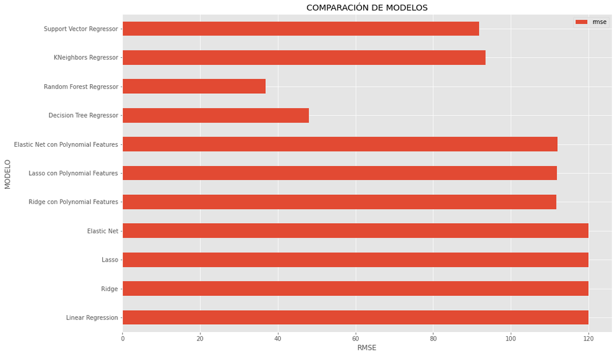

```python
df_comparacion = pd.DataFrame({'modelo': ['Linear Regression',
                                          'Ridge',
                                          'Lasso',
                                          'Elastic Net',
                                          'Ridge con Polynomial Features',
                                          'Lasso con Polynomial Features',
                                          'Elastic Net con Polynomial Features',
                                          'Decision Tree Regressor',
                                          'Random Forest Regressor',
                                          'KNeighbors Regressor',
                                          'Support Vector Regressor'],
                               'rmse': [rmse_linear_regression,
                                        rmse_ridge,
                                        rmse_lasso,
                                        rmse_elastic_net,
                                        rmse_poly_ridge,
                                        rmse_poly_lasso,
                                        rmse_poly_elastic_net,
                                        rmse_decision_tree_regressor,
                                        rmse_random_forest_regressor,
                                        rmse_k_neighbors_regressor,
                                        rmse_svr]
                              })

fig, ax = plt.subplots(figsize=(15, 10))
df_comparacion.set_index('modelo').plot(kind='barh', ax=ax)
ax.set_xlabel('RMSE')
ax.set_ylabel('MODELO')
ax.set_title('COMPARACIÓN DE MODELOS');
```

El modelo que va a ser capaz de determinar lo mejor posible cuántas bicicletas se van a alquilar a lo largo de una determinada hora, asumiendo que conocemos el calendario y las condiciones meteorológicas, será el Random Forest Regressor con un RMSE de 36.94. Las predicciones de este modelo final se alejan por lo tanto en promedio en 37 bicis del valor real.

```python
mejor_GridSearchCV = gs_random_forest_regressor
```

```python
mejor_Modelo = mejor_GridSearchCV.best_estimator_

mejor_GridSearchCV.best_params_
```

```
{'ccp_alpha': 0.0001,
 'criterion': 'mse',
 'max_depth': 59.4,
 'max_features': 'auto',
 'n_estimators': 493}
```

Se re-entrena el modelo.

```python
mejor_Modelo.fit(train_y_val[features], train_y_val["number_of_rentals"])
```

```
RandomForestRegressor(ccp_alpha=0.0001, max_depth=59.4, n_estimators=493)
```

## 7. Mediciones sobre el conjunto de test

Una vez que el modelo ganador ya ha sido seleccionado y entrenado con todo el conjunto de train, se procede a ver cómo predice en el conjunto de test. De esta forma, se sabrá qué resultados podemos esperar a futuro de dicho modelo.

Se saca el rmse en el conjunto de test (las predicciones del este modelo final se alejan en promedio en rmse bicis del valor real).

```python
import math

mse = mean_squared_error(y_true=test["number_of_rentals"],
                         y_pred=mejor_Modelo.predict(test[features]))

rmse = np.sqrt(mse)
rmse = math.ceil(rmse -0.5)

print("El modelo tiene un RMSE en el conjunto de test de "  +  str(rmse))
```

```
El modelo tiene un RMSE en el conjunto de test de 77
```

Los resultados que podemos esperar a futuro del modelo son que sus predicciones se alejarán en promedio en 77 bicis alquiladas a largo de una hora.

## 8. Guardar el modelo/pipeline para futuros usos

```python
import pickle

with open("mejor_Modelo_alquiler_de_bicicletas_marcos_paricio", "wb") as archivo_salida:
    pickle.dump(mejor_Modelo, archivo_salida)
```

The End